# DIAKITE-ADUAYOM-PROJET-ML-MATH

**Enseignant :** Claude PETIT

**Réalisé par :** DIAKITE Gaoussou et ADUAYOM MESSAN Daniel

**Année :** 2023/2024

MASTÈRE DATA SCIENCE - CONNAISSANCE CLIENT

Optimarketing: Modélisation Prédictive pour des Campagnes Marketing Ciblées

# Analyse des Campagnes Marketing

> Dans le contexte actuel où les achats en ligne sont de plus en plus courants, la société se trouve plongée dans une époque offrant un large éventail de choix, avec une multitude d'offres disponibles sur le marché. Face à cet environnement riche en options, il est pour les entreprises un véritable défi que de réussir à attirer efficacement l'attention des clients avec leurs nouvelles offres. La question essentielle qui se pose est donc de savoir comment atteindre un large public et susciter l'intérêt des consommateurs pour de nouveaux produits.

> Ces préoccupations sont devenues centrales pour les entreprises à l'ère numérique, où la concurrence est intense et les consommateurs sont inondés d'informations. Le paradigme de conversion vis-à-vis de l'offre s'est ainsi imposé comme un axe stratégique majeur. Dans le domaine du marketing digital, ce phénomène se manifeste particulièrement à travers des campagnes publicitaires qui visent à générer des taux de conversion significatifs. Face à cette dynamique, il devient impératif d'explorer de près la réaction et la réactivité des clients vis-à-vis de ces initiatives marketing, afin de mieux comprendre les mécanismes influençant leur engagement et leur prise de décision.

>

## 🔍 Contexte et Pertinence du Projet

> Dans ce contexte, nous avons décidé de mener une étude visant à approfondir notre compréhension de la réactivité des clients face à des campagnes, en tenant compte de leurs caractéristiques spécifiques. Une telle analyse approfondie de la clientèle revêt une importance cruciale, car elle permettra la conception de plans marketing plus précis, ciblés et susceptibles d'optimiser le nombre de conversions générées par des campagnes.

> Au-delà de cette compréhension initiale, notre objectif est d'établir ultérieurement un modèle de classification. En se basant sur les caractéristiques individuelles des clients, ce modèle nous permettra de prédire avec précision leur propension à être intéressés par l'offre présentée dans des campagnes publicitaires. Cette approche offre à une entreprise un avantage significatif en termes de gain de temps, en permettant de cibler de manière plus efficace les personnes susceptibles de convertir. Ils pourront ainsi adapter leur campagnes de manière optimale pour correspondre aux attentes de ceux qui n'ont pas encore manifesté d'intérêt face à leur offre initiale.

## 🎯 Objectifs Clés du Projet

> 1. **Exploration des Données :** Comme évoqué précédemment, notre étude se penchera sur une analyse approfondie des données afin de comprendre les caractéristiques et comportements des clients. L'objectif est d'identifier les différences entre ceux ayant montré de l'intérêt pour l'offre de la campagne et ceux qui n'en ont pas.
> 2. **Prétraitement des Données :** Par la suite, nous instaurerons un processus visant à créer de nouvelles variables et indicateurs, lesquels se révéleront utiles lors de la mise en œuvre du processus de modélisation.
> 3. **Modélisation de Classification :** Nous implémenterons des approches de machine learning pour anticiper la réaction des clients vis-à-vis des offres, introduisant ainsi de nouvelles dimensions dans notre processus de modélisation.
> 4. **Évaluation du Modèle :** Validation de la performance du modèle pour garantir sa fiabilité et son efficacité.

## 💡 Utilité et Impact du Projet

> Actuellement, les algorithmes de classification sont largement utilisés dans l'optimisation du marketing. Ils répondent efficacement aux besoins de compréhension de la clientèle et permettent d'anticiper leurs réactions au fil du temps. Cette approche offre aux entreprises une base solide pour améliorer leur retour sur investissement et générer des taux de conversion plus significatifs pour leurs offres de produits ou services.

# Présentation de la Base de Données

Dans cette section, nous présentons les variables de la base de données utilisée pour notre analyse, disponible [ici](https://www.kaggle.com/datasets/rodsaldanha/arketing-campaign/data?select=marketing_campaign.csv). Pour une meilleure compréhension, les noms des variables ont été renommés en français. Chaque variable est brièvement décrite, ce qui permet de comprendre sa signification et son importance dans l'analyse.

- **Identifiant :** Numéro d'identification unique pour chaque client.
- **Annee_Naissance :** Année de naissance du client.
- **Niveau_Education :** Niveau d'éducation atteint par le client.
- **Statut_Marital :** Statut marital du client.
- **Revenu :** Revenu annuel du foyer du client.
- **Nb_Enfants :** Nombre d'enfants dans le foyer du client.
- **Nb_Adolescents :** Nombre d'adolescents dans le foyer du client.
- **Date_Inscription :** Date à laquelle le client s'est inscrit auprès de l'entreprise.
- **Recence_Achat :** Nombre de jours écoulés depuis le dernier achat du client.
- **Depenses_Vins :** Montant dépensé en vins au cours des 2 dernières années.
- **Depenses_Fruits :** Montant dépensé en fruits au cours des 2 dernières années.
- **Depenses_Viandes :** Montant dépensé en produits de viande au cours des 2 dernières années.
- **Depenses_Poissons :** Montant dépensé en produits de poisson au cours des 2 dernières années.
- **Depenses_Sucreries :** Montant dépensé en produits sucrés au cours des 2 dernières années.
- **Depenses_Or :** Montant dépensé en produits d'or au cours des 2 dernières années.
- **Achats_Promos :** Nombre d'achats réalisés en promotion.
- **Achats_Web :** Nombre d'achats réalisés sur le site web de l'entreprise.
- **Achats_Catalogue :** Nombre d'achats réalisés à l'aide du catalogue.
- **Achats_Magasin :** Nombre d'achats réalisés directement en magasin.
- **VisitesWeb_Mois :** Nombre de visites sur le site web de l'entreprise par mois.
- **Campagne3_Acceptee :** Indique si le client a accepté l'offre lors de la 3ème campagne.
- **Campagne4_Acceptee :** Indique si le client a accepté l'offre lors de la 4ème campagne.
- **Campagne5_Acceptee :** Indique si le client a accepté l'offre lors de la 5ème campagne.
- **Campagne1_Acceptee :** Indique si le client a accepté l'offre lors de la 1ère campagne.
- **Campagne2_Acceptee :** Indique si le client a accepté l'offre lors de la 2ème campagne.
- **Plainte :** Indique si le client a déposé une plainte au cours des deux dernières années.
- **Cout_Contact :** Coût associé au contact avec le client .
- **Revenu_Z :** Revenu généré par le client pour l'entreprise .
- **Reponse :** Indique si le client a accepté l'offre lors de la dernière campagne.

```python
# Les bibliothèques qu'on va utiliser
import numpy as np
import pandas as pd
import matplotlib.pyplot as plt
import seaborn as sns
from IPython.display import display

import warnings
warnings.filterwarnings('ignore')  # Filtrer les avertissements

from sklearn.preprocessing import OneHotEncoder
from sklearn.linear_model import LogisticRegression
from sklearn.metrics import classification_report, confusion_matrix, accuracy_score, roc_curve, roc_auc_score
from sklearn.model_selection import GridSearchCV, train_test_split, RandomizedSearchCV, StratifiedKFold
from sklearn.tree import DecisionTreeClassifier, plot_tree
from sklearn.ensemble import GradientBoostingClassifier, RandomForestClassifier

from imblearn.over_sampling import SMOTE
from imblearn.pipeline import Pipeline as ImbPipeline
```

# Exploration de la Base de Données

L'exploration de la base de données est une étape essentielle de notre projet. C'est le moment où nous prenons connaissance en détail des données avec lesquelles nous allons travailler. Cette phase comprend plusieurs actions importantes :

- **Examen de la Structure des Données :** Nous commençons par observer la structure globale de la base de données. Cela inclut le nombre de lignes et de colonnes, ainsi que les types de données présents.
- **Identification des Valeurs Manquantes :** Nous cherchons à identifier les éventuelles valeurs manquantes dans les données, ce qui est crucial pour la qualité de notre analyse.
- **Renommage des Variables :** Pour faciliter la compréhension et le traitement des données, nous avons renommé les variables en français. Cette étape rend chaque variable plus claire et plus accessible.
- **Analyse Descriptive :** Nous effectuons une analyse descriptive des différentes variables. Cela implique de calculer des statistiques de base comme la moyenne, la médiane, les écarts-types, etc.

Cette exploration initiale nous permet de mieux comprendre les données et de préparer le terrain pour les analyses plus complexes à venir.

```python
# Lecture de la base de données
Data_Campagne = pd.read_csv("Data/marketing_campaign.csv", delimiter=";")
Data_Campagne.head()
```

|  | ID | Year_Birth | Education | Marital_Status | Income | Kidhome | Teenhome | Dt_Customer | Recency | MntWines | ... | NumWebVisitsMonth | AcceptedCmp3 | AcceptedCmp4 | AcceptedCmp5 | AcceptedCmp1 | AcceptedCmp2 | Complain | Z_CostContact | Z_Revenue | Response |
| --- | --- | --- | --- | --- | --- | --- | --- | --- | --- | --- | --- | --- | --- | --- | --- | --- | --- | --- | --- | --- | --- |
| 0 | 5524 | 1957 | Graduation | Single | 58138.0 | 0 | 0 | 2012-09-04 | 58 | 635 | ... | 7 | 0 | 0 | 0 | 0 | 0 | 0 | 3 | 11 | 1 |
| 1 | 2174 | 1954 | Graduation | Single | 46344.0 | 1 | 1 | 2014-03-08 | 38 | 11 | ... | 5 | 0 | 0 | 0 | 0 | 0 | 0 | 3 | 11 | 0 |
| 2 | 4141 | 1965 | Graduation | Together | 71613.0 | 0 | 0 | 2013-08-21 | 26 | 426 | ... | 4 | 0 | 0 | 0 | 0 | 0 | 0 | 3 | 11 | 0 |
| 3 | 6182 | 1984 | Graduation | Together | 26646.0 | 1 | 0 | 2014-02-10 | 26 | 11 | ... | 6 | 0 | 0 | 0 | 0 | 0 | 0 | 3 | 11 | 0 |
| 4 | 5324 | 1981 | PhD | Married | 58293.0 | 1 | 0 | 2014-01-19 | 94 | 173 | ... | 5 | 0 | 0 | 0 | 0 | 0 | 0 | 3 | 11 | 0 |

5 rows × 29 columns

### Taille de la Base de Données

Après examen de notre base de données, nous avons constaté qu'elle contient **2240 lignes** et **29 colonnes**. Cette taille indique que nous disposons d'un ensemble de données conséquent pour notre analyse, offrant une variété d'informations sur les clients et leurs interactions avec les différentes campagnes marketing.

La présence de nombreuses colonnes suggère une richesse en termes de variables disponibles, permettant une exploration approfondie des facteurs influençant les décisions des clients.

```python
# Affichage de la taille du Data_Campagne_cleanFrame
nombre_lignes = Data_Campagne.shape[0]
nombre_colonnes = Data_Campagne.shape[1]
print(f"La base de données contient {nombre_lignes} lignes et {nombre_colonnes} colonnes.")
```

```
La base de données contient 2240 lignes et 29 colonnes.
```

### Examen de la Structure des Données

L'examen de la structure de la base de données *Data_Campagne* indique principalement des données numériques (int64 et float64) et des chaînes de caractères (object). Cette étape clé nous oriente sur le traitement et l'analyse de chaque variable.

Ensuite, nous renommerons les variables pour les rendre plus explicites, facilitant ainsi les étapes ultérieures de nettoyage et d'analyse.

```python
# Examen de la structure des données
structure_info = Data_Campagne.info()
```

```
<class 'pandas.core.frame.DataFrame'>
RangeIndex: 2240 entries, 0 to 2239
Data columns (total 29 columns):
 #   Column               Non-Null Count  Dtype
---  ------               --------------  -----
 0   ID                   2240 non-null   int64
 1   Year_Birth           2240 non-null   int64
 2   Education            2240 non-null   object
 3   Marital_Status       2240 non-null   object
 4   Income               2216 non-null   float64
 5   Kidhome              2240 non-null   int64
 6   Teenhome             2240 non-null   int64
 7   Dt_Customer          2240 non-null   object
 8   Recency              2240 non-null   int64
 9   MntWines             2240 non-null   int64
```

[output cut: 21 more lines]

### Vérification Visuelle des Valeurs Manquantes

Nous avons créé une carte de chaleur pour visualiser les valeurs manquantes dans notre base de données. Cette méthode permet d'identifier rapidement les colonnes et les rangées qui contiennent des données incomplètes. Les zones jaunes sur la carte représentent les valeurs manquantes, nous aidant à comprendre l'étendue et la distribution des données manquantes dans l'ensemble de données.

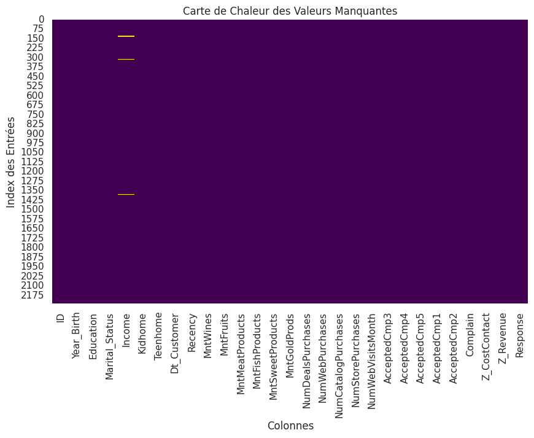

```python
# Vérification visuelle des valeurs manquantes
plt.figure(figsize=(10, 6))
sns.heatmap(Data_Campagne.isnull(), cbar=False, cmap='viridis')
plt.title('Carte de Chaleur des Valeurs Manquantes')
plt.xlabel('Colonnes')
plt.ylabel('Index des Entrées')
plt.show()
```

```python
nombre_valeurs_manquantes_income = Data_Campagne['Income'].isnull().sum()
print(f'Le nombre de valeur manquante dans la colonne Income est de {nombre_valeurs_manquantes_income}')
```

```
Le nombre de valeur manquante dans la colonne Income est de 24
```

### Commentaire sur les valeurs manquantes

Il s'avère qu'une seule colonne, `Income`, contient des valeurs manquantes dans notre base de données `Data_Campagne`. Le nombre total de ces valeurs manquantes est de 24. Il est important de connaître ce chiffre pour envisager une méthode d'imputation appropriée dans les étapes suivantes de notre analyse. Cette étape est essentielle pour garantir l'intégrité et la qualité de nos données avant de procéder à des analyses plus poussées.

### Renommage des Variables pour Plus de Clarté

Le processus de renommage des variables de notre base de données, appelée *Data_Campagne*, revêt une importance cruciale pour simplifier la compréhension et la manipulation des données. En attribuant des noms plus explicites et en français à chaque variable, nous améliorons l'accessibilité et la facilité de manipulation de notre jeu de données, notamment pour ceux qui privilégient la langue française dans leur travail.

Cette démarche vise à améliorer la lisibilité du code et à simplifier la communication des résultats de notre analyse, rendant le travail plus intuitif pour tous les utilisateurs potentiels du Data_Campagne_cleanset.

```python
# Affichage des noms des colonnes actuels
colonnes_actuelles = Data_Campagne.columns.tolist()
```

```python
# Renommage des colonnes
nouveaux_noms = {
    'ID': 'Identifiant',
    'Year_Birth': 'Annee_Naissance',
    'Education': 'Niveau_Education',
    'Marital_Status': 'Statut_Marital',
    'Income': 'Revenu',
    'Kidhome': 'Nb_Enfants',
    'Teenhome': 'Nb_Adolescents',
    'Dt_Customer': 'Date_Inscription',
    'Recency': 'Recence_Achat',
    'MntWines': 'Depenses_Vins',
    'MntFruits': 'Depenses_Fruits',
    'MntMeatProducts': 'Depenses_Viandes',
    'MntFishProducts': 'Depenses_Poissons',
    'MntSweetProducts': 'Depenses_Sucreries',
    'MntGoldProds': 'Depenses_Or',
    'NumDealsPurchases': 'Achats_Promos',
    'NumWebPurchases': 'Achats_Web',
    'NumCatalogPurchases': 'Achats_Catalogue',
    'NumStorePurchases': 'Achats_Magasin',
    'NumWebVisitsMonth': 'VisitesWeb_Mois',
    'AcceptedCmp3': 'Campagne3_Acceptee',
    'AcceptedCmp4': 'Campagne4_Acceptee',
    'AcceptedCmp5': 'Campagne5_Acceptee',
    'AcceptedCmp1': 'Campagne1_Acceptee',
    'AcceptedCmp2': 'Campagne2_Acceptee',
    'Complain': 'Plainte',
    'Z_CostContact': 'Cout_Contact',
    'Z_Revenue': 'Revenu_Z',
    'Response': 'Reponse'
}
```

```python
Data_Campagne.rename(columns=nouveaux_noms, inplace=True)

# Affichage des nouveaux noms de colonnes
Data_Campagne.columns
```

```
Index(['Identifiant', 'Annee_Naissance', 'Niveau_Education', 'Statut_Marital',
       'Revenu', 'Nb_Enfants', 'Nb_Adolescents', 'Date_Inscription',
       'Recence_Achat', 'Depenses_Vins', 'Depenses_Fruits', 'Depenses_Viandes',
       'Depenses_Poissons', 'Depenses_Sucreries', 'Depenses_Or',
       'Achats_Promos', 'Achats_Web', 'Achats_Catalogue', 'Achats_Magasin',
       'VisitesWeb_Mois', 'Campagne3_Acceptee', 'Campagne4_Acceptee',
       'Campagne5_Acceptee', 'Campagne1_Acceptee', 'Campagne2_Acceptee',
       'Plainte', 'Cout_Contact', 'Revenu_Z', 'Reponse'],
      dtype='object')
```

### Visualisation des Variables - Analyses Univariée et Bivariée

Dans cette partie, nous allons explorer visuellement nos données. L'analyse univariée nous permet de comprendre chaque variable individuellement, tandis que l'analyse bivariée met en lumière les relations et corrélations entre deux variables. Ces visualisations nous aideront à saisir les tendances, les anomalies et les motifs dans notre jeu de données.

Nous utiliserons des graphiques clairs et informatifs, avec des légendes et des annotations pour faciliter la compréhension des résultats.

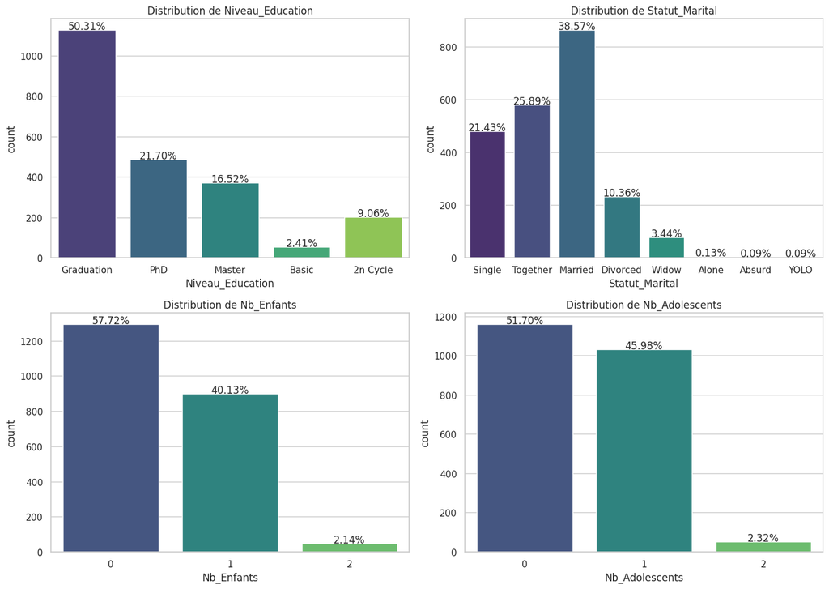

```python
# Utilisation d'un contexte de style Seaborn temporaire pour cette cellule uniquement
with sns.axes_style("whitegrid"):
    # Création d'une figure avec 4 sous-graphiques
    fig, axes = plt.subplots(2, 2, figsize=(14, 10))

    # Liste des colonnes à visualiser
    colonnes = ['Niveau_Education', 'Statut_Marital', 'Nb_Enfants', 'Nb_Adolescents']

    # Parcours des colonnes et création des histogrammes
    for i, col in enumerate(colonnes):
        ax = axes[i//2, i%2]
        total = float(len(Data_Campagne[col]))
        sns.countplot(x=col, data=Data_Campagne, palette="viridis", ax=ax)
        ax.set_title(f'Distribution de {col}')

        # Ajout des pourcentages sur les barres
        for p in ax.patches:
            height = p.get_height()
            ax.text(p.get_x() + p.get_width()/2.,
                    height + 3,
                    '{:1.2f}%'.format(100 * height/total),
                    ha="center")

    # Ajustement de l'espace entre les graphiques
    plt.tight_layout()
    plt.show()
```

### Interprétation des Distributions des Variables

**Niveau d'Éducation :** Avec 50.3% des clients diplômés (Graduation), cette catégorie domine nettement, suivie par les détenteurs d'un doctorat (PhD) à 21.7% et d'un Master à 16.5%. Les niveaux '2n Cycle' (9.1%) et 'Basic' (2.4%) sont moins représentés. Le niveau 'Basic' pourrait être combiné avec '2n Cycle' pour simplifier l'analyse, compte tenu de leur faible proportion.

**Statut Marital :** 'Married' (marié) est le statut le plus commun avec 38.6%, suivi de 'Together' (en couple) à 25.9% et 'Single' (célibataire) à 21.4%. Les catégories 'Divorced' (divorcé), 'Widow' (veuf) et les statuts moins courants comme 'Alone', 'Absurd' et 'YOLO' sont moins fréquents. Les statuts moins courants pourraient être regroupés en une seule catégorie 'Autre' pour une analyse plus claire.

**Nombre d'Enfants :** La majorité des clients (57.7%) n'ont pas d'enfants, et 40.1% ont un enfant. Seuls 2.1% des clients ont deux enfants, ce qui suggère une tendance vers des ménages plus petits.

**Nombre d'Adolescents :** Un peu plus de la moitié des clients (51.7%) n'ont pas d'adolescents, et 46% en ont un. Les familles avec deux adolescents sont rares (2.3%), reflétant une tendance similaire à celle observée avec le nombre d'enfants.

Ces informations fournissent des insights précieux sur la démographie des clients, essentiels pour élaborer des stratégies marketing ciblées et adaptées.

### Profil de la Clientèle

La clientèle de *notre base de données* est principalement composée de personnes bien éduquées, avec une majorité ayant atteint le niveau de graduation. Une grande partie de ces clients sont mariés ou en couple, de même qu'une proportion significative est célibataire. La plupart des clients ne possèdent pas d'enfants à charge, indiquant une tendance vers des ménages plus petits, composés principalement d'adultes ou de couples sans enfants. Cette composition démographique peut influencer leurs préférences de consommation et leurs comportements d'achat, orientant ainsi les stratégies marketing vers des produits et services adaptés à ce type de profil.

### Visualisation de nos variables de comptage

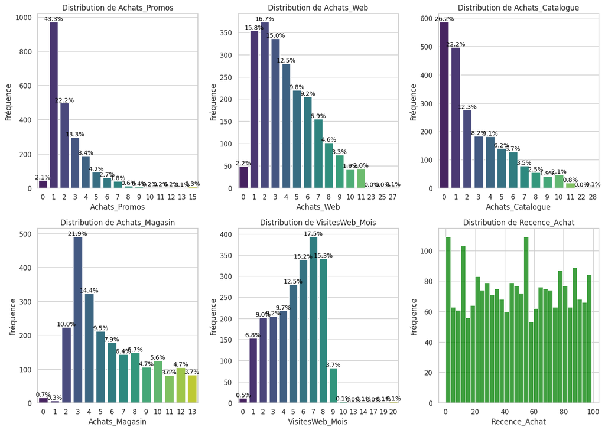

```python
# Utilisation d'un contexte de style Seaborn temporaire pour cette cellule uniquement
with sns.axes_style("whitegrid"):
    # Les noms de variables en français
    variables = ['Achats_Promos', 'Achats_Web', 'Achats_Catalogue', 'Achats_Magasin', 'VisitesWeb_Mois', 'Recence_Achat']

    # Création d'une figure avec plusieurs sous-graphiques
    fig, axes = plt.subplots(2, 3, figsize=(14, 10))  # Ajustement du nombre de sous-graphiques
    axes = axes.flatten()  # Aplatir le tableau des axes pour un accès facile

    # Parcours des variables pour créer des histogrammes/barplots
    for i, var in enumerate(variables):
        ax = axes[i]
        total = Data_Campagne[var].notnull().sum()  # Total pour le calcul des pourcentages

        if var == 'Recence_Achat':
            # Utiliser un histogramme pour 'Recence_Achat'
            histplot = sns.histplot(Data_Campagne[var], bins=30, ax=ax, color='green')
        else:
            # Utiliser des countplots pour les autres variables
            countplot = sns.countplot(x=var, data=Data_Campagne, ax=ax, palette='viridis')

        ax.set_title(f'Distribution de {var}')
        ax.set_xlabel(var)
        ax.set_ylabel('Fréquence')

        # Ajout des pourcentages sur les barres pour les barplots
        if var != 'Recence_Achat':
            for p in ax.patches:
                percentage = '{:.1f}%'.format(100 * p.get_height() / total)
                x = p.get_x() + p.get_width() / 2
                y = p.get_height()
                ax.annotate(percentage, (x, y), ha='center', va='center', fontsize=10, color='black', xytext=(0, 5), textcoords='offset points')

    # Suppression des axes supplémentaires s'il y en a
    for j in range(i + 1, len(axes)):
        fig.delaxes(axes[j])

    plt.tight_layout()
    plt.show()
```

### Interprétation des Comportements d'Achat et Visites Web

**Achats Promos :** La majorité des clients (43.3%) effectuent un achat en promotion, tandis que 22.2% en réalisent deux. Les achats promotionnels diminuent progressivement avec 13.3% pour trois achats et 8.4% pour quatre. Cela indique une tendance des clients à profiter des offres promotionnelles, mais avec une préférence marquée pour un nombre limité de promotions.

**Achats Web :** Les achats en ligne montrent une distribution variée, avec 16.7% des clients réalisant deux achats et 15.8% un seul. Les catégories avec trois à cinq achats sont également bien représentées (15%, 12.5% et 9.8% respectivement), soulignant l'importance du canal en ligne pour la clientèle.

**Achats Catalogue :** 26.2% des clients ne font pas d'achats via catalogue, tandis que 22.2% en font un. Les achats diminuent ensuite, avec 12.3% pour deux et environ 8% pour trois à quatre achats. Ce modèle suggère une utilisation modérée du catalogue par la majorité des clients.

**Achats Magasin :** Les achats en magasin sont dominés par trois achats (21.9%), suivis de quatre (14.4%) et deux (10%). Cela indique une tendance à faire des achats modérés en magasin parmi les clients.

**Visites Web par Mois :** Les visites web mensuelles sont les plus fréquentes à sept (17.5%) et huit (15.3%) fois par mois. Ceci, avec les catégories six et cinq visites (15.2% et 12.5%), montre un engagement régulier mais pas excessif avec le site web.

Cette analyse détaillée des comportements d'achat et des interactions en ligne, combinée avec le profil démographique des clients, révèle une clientèle variée avec une tendance à la modération dans ses achats et engagements en ligne. Cette tendance influence les stratégies marketing, suggérant un focus sur des offres modérées et ciblées pour répondre à leurs préférences.

### Visualisation de nos variables quantitatives

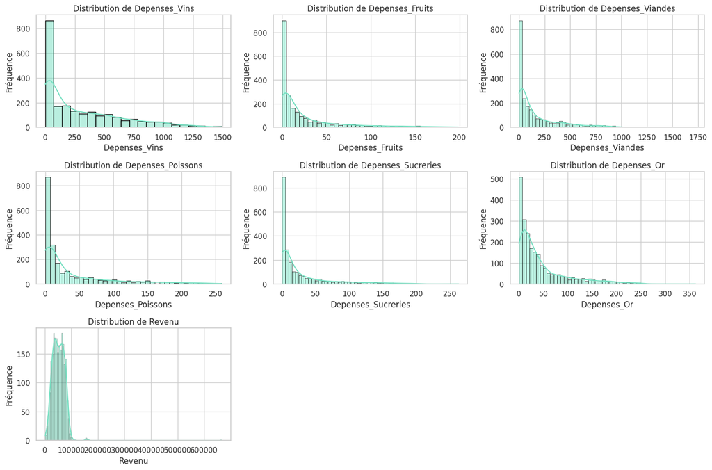

|  | count | mean | std | min | 25% | 50% | 75% | max |
| --- | --- | --- | --- | --- | --- | --- | --- | --- |
| Depenses_Vins | 2240.0 | 303.94 | 336.60 | 0.0 | 23.75 | 173.5 | 504.25 | 1493.0 |
| Depenses_Fruits | 2240.0 | 26.30 | 39.77 | 0.0 | 1.00 | 8.0 | 33.00 | 199.0 |
| Depenses_Viandes | 2240.0 | 166.95 | 225.72 | 0.0 | 16.00 | 67.0 | 232.00 | 1725.0 |
| Depenses_Poissons | 2240.0 | 37.53 | 54.63 | 0.0 | 3.00 | 12.0 | 50.00 | 259.0 |
| Depenses_Sucreries | 2240.0 | 27.06 | 41.28 | 0.0 | 1.00 | 8.0 | 33.00 | 263.0 |
| Depenses_Or | 2240.0 | 44.02 | 52.17 | 0.0 | 9.00 | 24.0 | 56.00 | 362.0 |
| Revenu | 2216.0 | 52247.25 | 25173.08 | 1730.0 | 35303.00 | 51381.5 | 68522.00 | 666666.0 |

```python
with sns.axes_style("whitegrid"):
    # Définition des variables à visualiser
    depenses_variables = ['Depenses_Vins', 'Depenses_Fruits', 'Depenses_Viandes',
                          'Depenses_Poissons', 'Depenses_Sucreries', 'Depenses_Or', 'Revenu']

    # Création d'une figure avec plusieurs sous-graphiques adaptés au nombre de variables
    fig, axes = plt.subplots(3, 3, figsize=(15, 10))  # Ajustement du nombre de sous-graphiques
    axes = axes.flatten()  # Aplatir le tableau des axes pour un accès facile

    # Parcours des variables pour créer des histogrammes
    for i, var in enumerate(depenses_variables):
        ax = axes[i]
        sns.histplot(Data_Campagne[var], kde=True, ax=ax, color='#75DFC1', edgecolor='black')
        ax.set_title(f'Distribution de {var}')
        ax.set_xlabel(var)
        ax.set_ylabel('Fréquence')

    # Suppression des axes supplémentaires non utilisés
    for j in range(i + 1, len(axes)):
        fig.delaxes(axes[j])

    plt.tight_layout()
    plt.show()

# Affichage des statistiques descriptives
stats_desc_table = Data_Campagne[depenses_variables].describe()
stats_desc_table = stats_desc_table.round(2)
display(stats_desc_table.T)
```

### Analyse des Dépenses des Clients

L'analyse des dépenses des clients révèle des informations intéressantes sur leurs habitudes d'achat. Les dépenses moyennes en vins sont de 303.94 €, avec un maximum de 1493 €, indiquant un goût prononcé pour les produits de luxe chez certains clients. Les fruits, avec une moyenne de 26.30 € et un maximum de 199 €, et les viandes, avec une moyenne de 166.95 € et un maximum de 1725 €, montrent des habitudes d'achat variées, allant de dépenses modérées à des achats plus importants.

Les dépenses en poissons (moyenne de 37.53 €, maximum de 259 €) et en sucreries (moyenne de 27.06 €, maximum de 263 €) sont généralement plus modérées, mais avec des pics qui peuvent indiquer des préférences spécifiques ou des achats occasionnels de luxe. Enfin, les dépenses en or, avec une moyenne de 44.02 € et un maximum de 362 €, peuvent refléter des achats ponctuels ou des cadeaux.

Ces données mettent en évidence une clientèle ayant des préférences diverses, avec une inclinaison pour des produits de qualité ou de luxe dans certaines catégories. Cela suggère des opportunités de marketing ciblé, en se concentrant sur les produits de luxe et de qualité pour répondre aux besoins de cette clientèle.

### Interprétation des Statistiques des Revenus des Clients

L'analyse des revenus des clients de notre base de données montre une moyenne de 52,247.25 €, avec un écart-type de 25,173.08 €, indiquant une variabilité significative dans les niveaux de revenu. Le revenu minimum observé est de 1,730 €.

La médiane des revenus, s'établissant à 51,381.50 €, suggère que la moitié des clients gagnent moins que ce montant tandis que l'autre moitié gagne plus. Le premier quartile à 35,303 € et le troisième quartile à 68,522 € montrent que 25% des clients ont des revenus relativement bas, tandis que 25% ont des revenus nettement plus élevés.

Compte tenu de ces données, ainsi que des informations précédemment fournies sur les habitudes d'achat et les réponses aux campagnes, nous pouvons déduire que notre clientèle est assez diversifiée en termes de pouvoir d'achat. Une portion significative de la clientèle semble avoir une capacité financière élevée, ce qui pourrait influencer leurs décisions d'achat et leur réponse aux campagnes marketing, en particulier celles liées à des produits de luxe ou de qualité supérieure.

Ces informations sont cruciales pour le ciblage marketing et la personnalisation des campagnes pour répondre efficacement aux besoins et préférences de différents segments de clients.

### Visualisation de nos variables de Campagnes Historiques

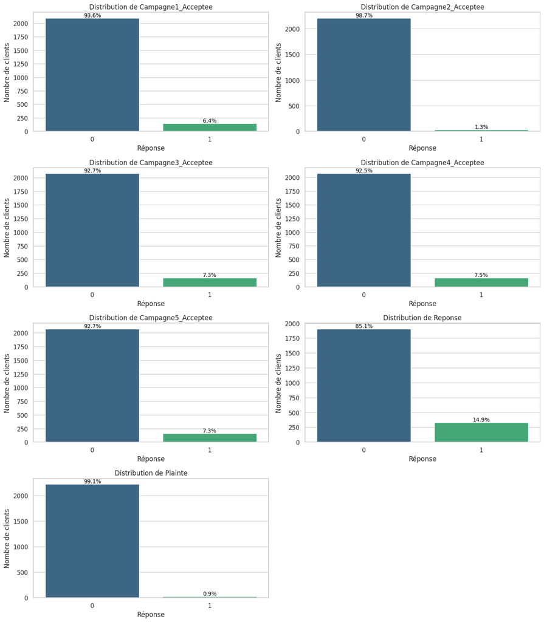

```python
# Définition des variables relatives aux campagnes acceptées et la cible (Réponse)
campagnes_variables = ['Campagne1_Acceptee', 'Campagne2_Acceptee', 'Campagne3_Acceptee',
                       'Campagne4_Acceptee', 'Campagne5_Acceptee', 'Reponse', 'Plainte']

# Utilisation d'un contexte de style Seaborn temporaire pour cette cellule uniquement
with sns.axes_style("whitegrid"):
    # Création d'une figure avec plusieurs sous-graphiques
    fig, axes = plt.subplots(4, 2, figsize=(14, 16))

    # Aplatir le tableau des axes pour un accès facile
    axes = axes.flatten()

    # Parcours des variables pour créer des histogrammes
    for i, var in enumerate(campagnes_variables):
        ax = axes[i]
        total = Data_Campagne[var].notnull().sum()  # Total pour le calcul des pourcentages
        countplot = sns.countplot(x=var, data=Data_Campagne, ax=ax, palette='viridis')
        ax.set_title(f'Distribution de {var}')
        ax.set_xlabel('Réponse')
        ax.set_ylabel('Nombre de clients')

        # Ajout des pourcentages sur les barres
        for p in ax.patches:
            percentage = '{:.1f}%'.format(100 * p.get_height() / total)
            x = p.get_x() + p.get_width() / 2
            y = p.get_height()
            ax.annotate(percentage, (x, y), ha='center', va='center', fontsize=10, color='black', xytext=(0, 5), textcoords='offset points')

    # Suppression des axes inutilisés si nécessaire
    for j in range(i + 1, len(axes)):
        fig.delaxes(axes[j])

    plt.tight_layout()
    plt.show()
```

### Interprétation des Réponses aux Campagnes Marketing et Plaintes

Nos analyses des réponses aux différentes campagnes marketing et des plaintes des clients révèlent des informations cruciales. Concernant les campagnes, nous observons que les taux d'acceptation varient, avec des pourcentages plus faibles pour les premières campagnes (6.43% pour la première et 1.34% pour la deuxième) et légèrement plus élevés pour les campagnes suivantes (autour de 7% pour les troisième, quatrième et cinquième campagnes).

La variable "Réponse", qui indique l'acceptation de l'offre lors de la dernière campagne, montre que 14.91% des clients ont accepté l'offre, contre 85.09% qui ne l'ont pas fait. Cela met en évidence le défi de concevoir des campagnes qui résonnent davantage avec les préférences des clients.

En ce qui concerne la variable "Plainte", nous constatons que seulement 0.94% des clients ont déposé une plainte, ce qui indique un niveau de satisfaction globalement élevé parmi les clients, avec 99.06% n'ayant pas exprimé de plainte officielle.

Ces données offrent des perspectives précieuses pour l'optimisation des campagnes marketing futures, en soulignant l'importance de cibler efficacement les clients et de maintenir un haut niveau de satisfaction.

# Traitement de la Base de Données

### 🔄 Prétraitement des Données

Le prétraitement des données est une étape essentielle pour préparer notre analyse et nos modèles de machine learning. Nous allons nous concentrer sur plusieurs aspects clés : l'imputation, la discrétisation et le regroupement des modalités.

#### Imputation des Valeurs Manquantes

Nous commencerons par gérer les valeurs manquantes, notamment dans la variable 'Revenu', en utilisant une méthode d'imputation adaptée à sa distribution.

#### Discrétisation des Variables Continues et Calcul de l'Âge et de l'Ancienneté

Nous discrétiserons les variables 'Revenu' et les différentes catégories de dépenses ('Vins', 'Fruits', 'Viandes', 'Poissons', 'Sucreries', 'Or') en se basant sur leurs statistiques descriptives. De plus, nous calculerons l'âge des clients à partir de leur année de naissance, en considérant 2019 comme l'année de référence, et l'ancienneté à partir de leur date d'inscription.

#### Regroupement des Modalités

Pour les variables telles que 'Statut Marital', 'Achats Promos', 'Achats Web', 'Achats Catalogue', 'Achats Magasin', 'Visites Web par Mois', et les réponses aux campagnes, nous regrouperons les modalités ayant moins de valeurs pour simplifier l'analyse et améliorer la performance des modèles.

Ces étapes de traitement sont vitales pour assurer la qualité des données et leur pertinence pour l'analyse. Un prétraitement méticuleux permet d'obtenir des résultats d'analyse plus fiables et des modèles prédictifs plus précis.

# Traitement de la Base de Données

### 🔄 Prétraitement des Données

Le prétraitement des données est une étape essentielle pour préparer notre analyse et nos modèles de machine learning. Nous allons nous concentrer sur plusieurs aspects clés : l'imputation, la discrétisation et le regroupement des modalités.

#### **Imputation des Valeurs Manquantes**

Nous commencerons par gérer les valeurs manquantes, notamment dans la variable 'Revenu', en utilisant une méthode d'imputation adaptée à sa distribution.

#### **Discrétisation des Variables Continues et Calcul de l'Âge et de l'Ancienneté**

Nous discrétiserons les variables 'Revenu' et les différentes catégories de dépenses ('Vins', 'Fruits', 'Viandes', 'Poissons', 'Sucreries', 'Or') en se basant sur leurs statistiques descriptives. De plus, nous calculerons l'âge des clients à partir de leur année de naissance, en considérant 2019 comme l'année de référence, et l'ancienneté à partir de leur date d'inscription.

#### **Regroupement des Modalités**

Pour les variables telles que 'Statut Marital', 'Achats Promos', 'Achats Web', 'Achats Catalogue', 'Achats Magasin', 'Visites Web par Mois', et les réponses aux campagnes, nous regrouperons les modalités ayant moins de valeurs pour simplifier l'analyse et améliorer la performance des modèles.

Ces étapes de traitement sont vitales pour assurer la qualité des données et leur pertinence pour l'analyse. Un prétraitement méticuleux permet d'obtenir des résultats d'analyse plus fiables et des modèles prédictifs plus précis.

### Imputation de la Variable 'Revenu'

Lors de l'analyse des données, il est courant de rencontrer des valeurs manquantes. Pour la variable 'Revenu', nous avons choisi d'imputer ces valeurs manquantes en utilisant la médiane. Cette décision est basée sur la nature de la distribution des revenus observée dans nos données.

La distribution des revenus présente une large gamme, avec une moyenne de 52,247.25 € et une médiane de 51,381.50 €. Cette différence suggère une distribution asymétrique, probablement influencée par des valeurs extrêmes. Dans de telles situations, la médiane est souvent préférée à la moyenne pour l'imputation car elle est moins sensible à ces valeurs extrêmes.

En imputant les valeurs manquantes par la médiane, nous nous assurons que notre traitement des données reflète de manière plus fidèle la tendance centrale des revenus de nos clients, sans être faussé par les valeurs aberrantes. Cette approche contribue à maintenir l'intégrité des analyses subséquentes et des modèles prédictifs que nous développerons.

```python
# Calcul de la médiane pour la colonne 'Revenu'
revenu_median = Data_Campagne['Revenu'].median()

# Imputation des valeurs manquantes par la médiane
Data_Campagne['Revenu'].fillna(revenu_median, inplace=True)


# Calcul des statistiques descriptives pour 'Revenu'
stats_desc_revenu = Data_Campagne["Revenu"].describe().round(2)

# Convertir en DataFrame pour pouvoir transposer
stats_desc_revenu_df = pd.DataFrame(stats_desc_revenu)

# Transposition du tableau pour une meilleure présentation
stats_desc_revenu_transposed = stats_desc_revenu_df.T

# Affichage du tableau transposé
display(stats_desc_revenu_transposed)
```

|  | count | mean | std | min | 25% | 50% | 75% | max |
| --- | --- | --- | --- | --- | --- | --- | --- | --- |
| Revenu | 2240.0 | 52237.98 | 25037.96 | 1730.0 | 35538.75 | 51381.5 | 68289.75 | 666666.0 |

### Discrétisation de la Variable 'Revenu'

La discrétisation de la variable 'Revenu' est une étape clé pour simplifier les analyses ultérieures et améliorer la performance des modèles prédictifs. Nous utiliserons les quartiles pour diviser les revenus en quatre catégories distinctes.

Cette méthode de discrétisation nous permet de transformer les données continues du revenu en catégories plus maniables, facilitant la compréhension des tendances et des patterns au sein de notre clientèle.

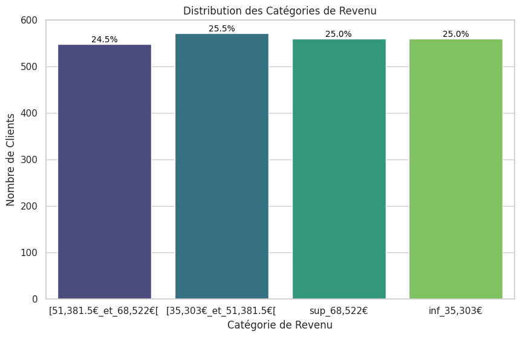

```python
# Détermination des quartiles
quartile1 = Data_Campagne['Revenu'].quantile(0.25)
quartile2 = Data_Campagne['Revenu'].quantile(0.5)  # Médiane
quartile3 = Data_Campagne['Revenu'].quantile(0.75)

# Fonction pour catégoriser chaque revenu en classes nominales
def categorize_revenue(revenue):
    if revenue <= quartile1:
        return 'inf_35,303€'  # Revenus inférieurs au premier quartile
    elif quartile1 < revenue <= quartile2:
        return '[35,303€_et_51,381.5€['  # Revenus entre le premier quartile et la médiane
    elif quartile2 < revenue <= quartile3:
        return '[51,381.5€_et_68,522€['  # Revenus entre la médiane et le troisième quartile
    else:
        return 'sup_68,522€'  # Revenus supérieurs au troisième quartile

# Application de la fonction de catégorisation au DataFrame
Data_Campagne['Categorie_Revenu'] = Data_Campagne['Revenu'].apply(categorize_revenue)

#Utilisation d'un contexte de style Seaborn temporaire pour cette cellule uniquement
with sns.axes_style("whitegrid"):
    plt.figure(figsize=(10, 6))
    ax = sns.countplot(x='Categorie_Revenu', data=Data_Campagne, palette='viridis')
    ax.set_title('Distribution des Catégories de Revenu')
    ax.set_xlabel('Catégorie de Revenu')
    ax.set_ylabel('Nombre de Clients')

    # Calcul et affichage des pourcentages sur les barres
    total = len(Data_Campagne['Categorie_Revenu'])
    for p in ax.patches:
        percentage = '{:.1f}%'.format(100 * p.get_height() / total)
        x = p.get_x() + p.get_width() / 2
        y = p.get_height()
        ax.annotate(percentage, (x, y), ha='center', va='center', fontsize=10, color='black', xytext=(0, 5), textcoords='offset points')

    plt.show()
```

### Interprétation des Catégories de Revenu Après Discrétisation

Cette distribution presque uniforme montre que notre base de données couvre un large éventail de groupes de revenus, reflétant ainsi une diversité économique au sein de notre clientèle. Cette variété dans les segments de revenus est un atout pour des analyses et des stratégies marketing ciblées.

### Discrétisation des Dépenses des Clients

Afin de faciliter l'analyse et la modélisation, nous allons discrétiser les dépenses des clients dans différentes catégories (vins, fruits, viandes, poissons, sucreries, et or) en se basant sur les statistiques descriptives de chaque variable.

Cette discrétisation aide à simplifier les variables continues et à mettre en évidence les différents profils de dépenses des clients, ce qui est essentiel pour des analyses ciblées et des stratégies marketing personnalisées.

```python
# Liste des colonnes de dépenses
depense_cols = ['Depenses_Vins', 'Depenses_Fruits', 'Depenses_Viandes', 'Depenses_Poissons', 'Depenses_Sucreries', 'Depenses_Or']

# Création d'un DataFrame pour stocker les statistiques descriptives transposées
stats_desc_all = pd.DataFrame()

# Calcul et affichage des statistiques descriptives pour chaque colonne de dépense
for col in depense_cols:
    stats_desc = Data_Campagne[col].describe().round(2)
    stats_desc_df = pd.DataFrame(stats_desc)
    stats_desc_transposed = stats_desc_df.T
    stats_desc_all = pd.concat([stats_desc_all, stats_desc_transposed])

# Affichage du tableau regroupant toutes les statistiques descriptives transposées
display(stats_desc_all)
```

|  | count | mean | std | min | 25% | 50% | 75% | max |
| --- | --- | --- | --- | --- | --- | --- | --- | --- |
| Depenses_Vins | 2240.0 | 303.94 | 336.60 | 0.0 | 23.75 | 173.5 | 504.25 | 1493.0 |
| Depenses_Fruits | 2240.0 | 26.30 | 39.77 | 0.0 | 1.00 | 8.0 | 33.00 | 199.0 |
| Depenses_Viandes | 2240.0 | 166.95 | 225.72 | 0.0 | 16.00 | 67.0 | 232.00 | 1725.0 |
| Depenses_Poissons | 2240.0 | 37.53 | 54.63 | 0.0 | 3.00 | 12.0 | 50.00 | 259.0 |
| Depenses_Sucreries | 2240.0 | 27.06 | 41.28 | 0.0 | 1.00 | 8.0 | 33.00 | 263.0 |
| Depenses_Or | 2240.0 | 44.02 | 52.17 | 0.0 | 9.00 | 24.0 | 56.00 | 362.0 |

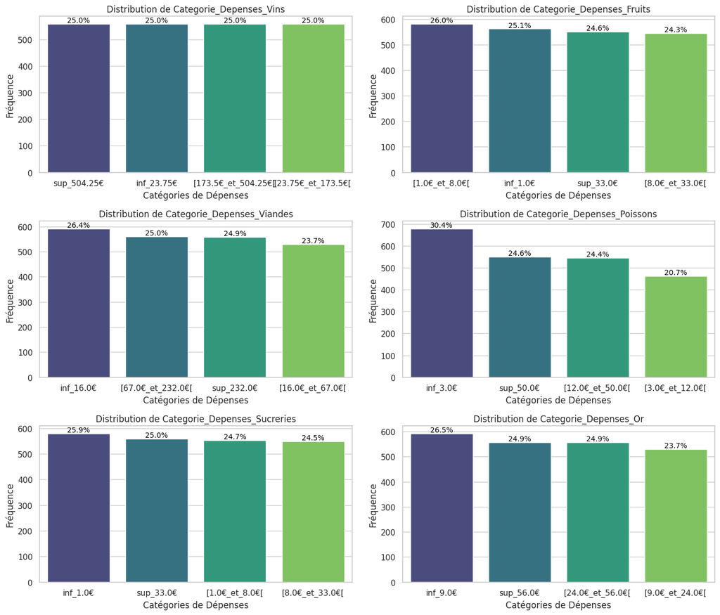

```python
def categorize_expenses(value, quartiles):
    if value <= quartiles[0.25]:
        return f"inf_{quartiles[0.25]}€"
    elif value <= quartiles[0.50]:
        return f"[{quartiles[0.25]}€_et_{quartiles[0.50]}€["
    elif value <= quartiles[0.75]:
        return f"[{quartiles[0.50]}€_et_{quartiles[0.75]}€["
    else:
        return f"sup_{quartiles[0.75]}€"

# Application de la discrétisation pour chaque variable de dépense
depense_cols = ['Depenses_Vins', 'Depenses_Fruits', 'Depenses_Viandes', 'Depenses_Poissons', 'Depenses_Sucreries', 'Depenses_Or']
for col in depense_cols:
    quartiles = Data_Campagne[col].quantile([0.25, 0.50, 0.75])
    Data_Campagne[f'Categorie_{col}'] = Data_Campagne[col].apply(lambda x: categorize_expenses(x, quartiles))

#----------------------------------------------------------------------------------

# Utilisation d'un contexte de style Seaborn temporaire pour cette cellule uniquement
with sns.axes_style("whitegrid"):
    # Création d'une figure avec plusieurs sous-graphiques
    fig, axes = plt.subplots(3, 2, figsize=(14, 12))
    axes = axes.flatten()  # Aplatir le tableau des axes pour un accès facile

    # Liste des colonnes de dépenses discrétisées à visualiser
    depense_cols = ['Categorie_Depenses_Vins', 'Categorie_Depenses_Fruits', 'Categorie_Depenses_Viandes',
                    'Categorie_Depenses_Poissons', 'Categorie_Depenses_Sucreries', 'Categorie_Depenses_Or']

    # Parcours des colonnes pour créer des histogrammes
    for ax, col in zip(axes, depense_cols):
        total = len(Data_Campagne[col])  # Total pour le calcul des pourcentages
        order = Data_Campagne[col].value_counts().index  # Ordre basé sur la fréquence
        countplot = sns.countplot(x=col, data=Data_Campagne, ax=ax, palette='viridis', order=order)
        ax.set_title(f'Distribution de {col}')
        ax.set_xlabel('Catégories de Dépenses')
        ax.set_ylabel('Fréquence')

        # Ajout des pourcentages sur les barres
        for p in ax.patches:
            percentage = '{:.1f}%'.format(100 * p.get_height() / total)
            x = p.get_x() + p.get_width() / 2
            y = p.get_height()
            ax.annotate(percentage, (x, y), ha='center', va='center', fontsize=10, color='black', xytext=(0, 5), textcoords='offset points')

    plt.tight_layout()
    plt.show()
```

### Calcul de l'Âge et de l'Ancienneté des Clients

Pour mieux comprendre notre clientèle, nous avons calculé l'âge et l'ancienneté de nos clients. L'âge a été déduit à partir de l'année de naissance, en considérant 2019 comme l'année actuelle. L'ancienneté a été calculée à partir de la date d'inscription, en prenant également 2019 comme référence.

### Discrétisation de l'Âge

Après avoir calculé l'âge, nous avons procédé à sa discrétisation en se basant sur les quartiles de la distribution des âges. Cela nous a permis de diviser les âges en quatre catégories distinctes :

- **Inférieur à 42 ans :** Regroupe les jeunes adultes.
- **Entre 42 et 49 ans :** Catégorise les adultes moyens.
- **Entre 49 et 60 ans :** Correspond aux adultes supérieurs.
- **Supérieur à 60 ans :** Englobe les seniors.

Cette approche de discrétisation nous aide à mieux cerner les différents groupes d'âge au sein de notre clientèle, facilitant ainsi l'analyse démographique et la segmentation pour des stratégies marketing ciblées.

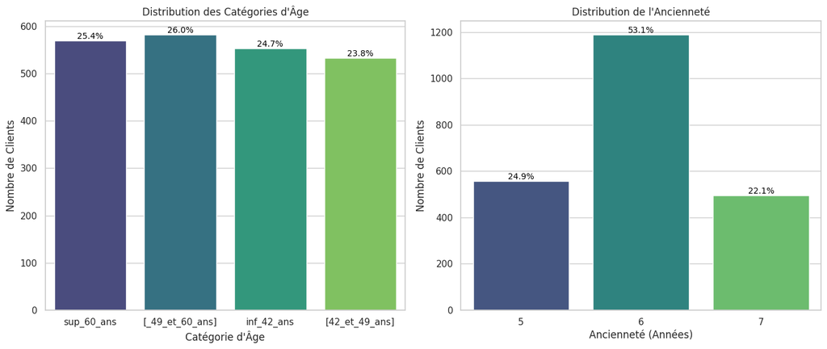

```python
# Calcul de l'âge en 2019 (parce que les  données ont été mis sur le site depuis 2019 )
Data_Campagne['Age'] = 2019 - Data_Campagne['Annee_Naissance']

# Conversion de 'Date_Inscription' en type datetime
Data_Campagne['Date_Inscription'] = pd.to_datetime(Data_Campagne['Date_Inscription'])

# Calcul de l'ancienneté en 2019
Data_Campagne['Anciennete'] = 2019 - Data_Campagne['Date_Inscription'].dt.year

#---------------------------------------------------------------

# Fonction pour catégoriser l'âge en fonction des quartiles
def categorize_age(age):
    if age < 42:
        return 'inf_42_ans'  # Jeunes Adultes
    elif 42 <= age < 49:
        return '[42_et_49_ans]'  # Adultes Moyens
    elif 49 <= age < 60:
        return '[_49_et_60_ans]'  # Adultes Supérieurs
    else:
        return 'sup_60_ans'  # Seniors

# Application de la catégorisation à la colonne 'Age'
Data_Campagne['Categorie_Age'] = Data_Campagne['Age'].apply(categorize_age)



#------------------------------------------------------------------------------


# Utilisation d'un contexte de style Seaborn temporaire pour cette cellule uniquement
with sns.axes_style("whitegrid"):
    # Création de deux sous-graphiques
    fig, axes = plt.subplots(1, 2, figsize=(14, 6))

    # Histogramme pour l'âge discrétisé
    ax1 = sns.countplot(x='Categorie_Age', data=Data_Campagne, palette='viridis', ax=axes[0])
    ax1.set_title('Distribution des Catégories d\'Âge')
    ax1.set_xlabel('Catégorie d\'Âge')
    ax1.set_ylabel('Nombre de Clients')
    # Ajout des pourcentages sur les barres
    total_age = len(Data_Campagne['Categorie_Age'])
    for p in ax1.patches:
        percentage_age = '{:.1f}%'.format(100 * p.get_height() / total_age)
        ax1.annotate(percentage_age, (p.get_x() + p.get_width() / 2., p.get_height()),
                     ha='center', va='center', fontsize=10, color='black',
                     xytext=(0, 5), textcoords='offset points')

    # Histogramme pour l'ancienneté
    ax2 = sns.countplot(x='Anciennete', data=Data_Campagne, palette='viridis', ax=axes[1])
    ax2.set_title('Distribution de l\'Ancienneté')
    ax2.set_xlabel('Ancienneté (Années)')
    ax2.set_ylabel('Nombre de Clients')
    # Ajout des pourcentages sur les barres
    total_anciennete = len(Data_Campagne['Anciennete'])
    for p in ax2.patches:
        percentage_anciennete = '{:.1f}%'.format(100 * p.get_height() / total_anciennete)
        ax2.annotate(percentage_anciennete, (p.get_x() + p.get_width() / 2., p.get_height()),
                     ha='center', va='center', fontsize=10, color='black',
                     xytext=(0, 5), textcoords='offset points')

    plt.tight_layout()
    plt.show()
```

### Analyse des Catégories d'Âge et de l'Ancienneté

L'analyse de la distribution des catégories d'âge après discrétisation montre une répartition relativement équilibrée entre les différents groupes :

- **Entre 49 et 60 ans :** Représente la plus grande proportion avec 26.03% des clients.
- **Plus de 60 ans :** Constitue 25.45% de la clientèle.
- **Moins de 42 ans :** Comprend 24.73% des clients.
- **Entre 42 et 49 ans :** Constitue 23.79% des clients.

Cette distribution équilibrée indique une diversité d'âge au sein de notre clientèle, ce qui peut avoir un impact significatif sur les stratégies marketing et la personnalisation des offres.

En ce qui concerne l'ancienneté, nous observons la répartition suivante :

- **6 ans :** La majorité des clients (53.08%) sont inscrits depuis 6 ans.
- **5 ans :** Représente 24.87% des clients.
- **7 ans :** Constitue 22.05% de la base de données.

L'ancienneté élevée de nombreux clients suggère une base de clients fidèles, offrant des opportunités pour des stratégies de fidélisation et de valorisation à long terme.

### Regroupement Stratégique des Modalités

Dans le but de simplifier notre analyse et d'optimiser nos modèles prédictifs, nous avons effectué des regroupements judicieux des modalités pour des variables clés. Ce processus implique de rassembler les catégories moins fréquentes afin de créer des groupes plus significatifs et représentatifs.

- **Statut Marital :** Les statuts moins courants comme "Absurd" et "YOLO" ont été retiré de notre jeu de données, pour mieux refléter les situations maritales prédominantes.
- **Achats (Promos, Web, Catalogue, Magasin) :** Les catégories d'achats ont été regroupées selon leur fréquence, créant des intervalles clairs (0, 1, 2-4, 5-7, 8+) qui facilitent l'interprétation des habitudes d'achat.
- **Visites Web par Mois :** Similairement, les visites web ont été consolidées en groupes significatifs basés sur leur nombre (0, 1, 2-4, 5-7, 8+), permettant une analyse plus claire des comportements de navigation.

Ces regroupements réduisent la fragmentation des données et améliorent la clarté des analyses. En concentrant notre attention sur les catégories les plus pertinentes, nous pouvons mieux cerner les tendances dominantes et les préférences de nos clients.

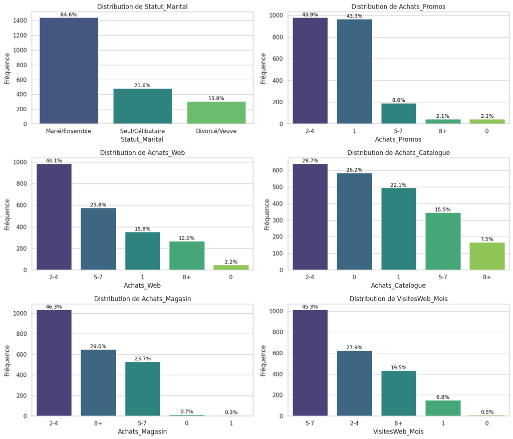

```python
# Regroupement pour Statut Marital

# Supprimer les lignes où Statut_Marital est 'Absurd' ou 'YOLO'
Data_Campagne = Data_Campagne[~Data_Campagne['Statut_Marital'].isin(['Absurd', 'YOLO'])]
Data_Campagne['Statut_Marital'] = Data_Campagne['Statut_Marital'].replace(['Divorced', 'Widow'], 'Divorcé/Veuve')
Data_Campagne['Statut_Marital'] = Data_Campagne['Statut_Marital'].replace(['Married', 'Together'], 'Marié/Ensemble')
Data_Campagne['Statut_Marital'] = Data_Campagne['Statut_Marital'].replace(['Single', 'Alone'], 'Seul/Célibataire')


# Fonction de regroupement pour les achats et les visites web
def regroup_achats_visites(x):
    if x == 0:
        return '0'
    elif x == 1:
        return '1'
    elif x in [2, 3, 4]:
        return '2-4'
    elif x in [5, 6, 7]:
        return '5-7'
    else:
        return '8+'

# Application du regroupement aux colonnes d'achats et de visites web
for col in ['Achats_Promos', 'Achats_Web', 'Achats_Catalogue', 'Achats_Magasin', 'VisitesWeb_Mois']:
    Data_Campagne[col] = Data_Campagne[col].apply(regroup_achats_visites)

# Visualisation des distributions après regroupement
import seaborn as sns
import matplotlib.pyplot as plt

# Utilisation d'un contexte de style Seaborn temporaire pour cette cellule uniquement
with sns.axes_style("whitegrid"):
    # Création d'une figure avec plusieurs sous-graphiques
    fig, axes = plt.subplots(3, 2, figsize=(14, 12))
    axes = axes.flatten()  # Aplatir le tableau des axes pour un accès facile

    # Liste des colonnes à visualiser
    colonnes = ['Statut_Marital', 'Achats_Promos', 'Achats_Web', 'Achats_Catalogue', 'Achats_Magasin', 'VisitesWeb_Mois']

    # Parcours des colonnes pour créer des histogrammes
    for ax, col in zip(axes, colonnes):
        total = Data_Campagne[col].notnull().sum()  # Total pour le calcul des pourcentages
        order = Data_Campagne[col].value_counts().index  # Ordre basé sur la fréquence
        countplot = sns.countplot(x=col, data=Data_Campagne, ax=ax, palette='viridis', order=order)
        ax.set_title(f'Distribution de {col}')
        ax.set_xlabel(col)
        ax.set_ylabel('Fréquence')

        # Ajout des pourcentages sur les barres
        for p in ax.patches:
            percentage = '{:.1f}%'.format(100 * p.get_height() / total)
            x = p.get_x() + p.get_width() / 2
            y = p.get_height()
            ax.annotate(percentage, (x, y), ha='center', va='center', fontsize=10, color='black', xytext=(0, 5), textcoords='offset points')

    plt.tight_layout()
    plt.show()
```

### Résumé des Résultats Après Regroupement des Modalités

Le regroupement des modalités des variables a permis de dégager des tendances claires dans le comportement de nos clients. Voici un aperçu des résultats obtenus :

- **Statut Marital :** La majorité des clients maintiennent soit une rélation (64.60%) ou célibataires (21.60%), avec 13,80% des clients qui sont divorcés ou veuve.
- **Achats Promos :** Les catégories '2-4' et '1' représentent la grande majorité des achats promotionnels, montrant une préférence pour des achats modérés en promotions.
- **Achats Web :** Les catégories '2-4' et '5-7' sont les plus représentées pour les achats en ligne, indiquant une activité régulière sur le site web.
- **Achats Catalogue :** Une répartition équilibrée entre les catégories '2-4', '0' et '1' montre une variété dans l'utilisation du catalogue pour les achats.
- **Achats Magasin :** Les achats en magasin sont concentrés dans les catégories '2-4' et '8+', reflétant une tendance aux achats modérés ou élevés en magasin.
- **Visites Web par Mois :** La majorité des clients visitent le site web entre '5-7' et '2-4' fois par mois, dénotant un engagement régulier mais mesuré avec la plateforme en ligne.

Ces insights fournissent des informations précieuses sur les habitudes et les préférences de notre clientèle, aidant à orienter les décisions marketing et les initiatives d'engagement.

### Discrétisation de la Récence des Achats

La variable 'Recence_Achat', qui mesure le nombre de jours écoulés depuis le dernier achat d'un client, est un indicateur clé de l'engagement et de la fidélité des clients. Pour faciliter son analyse, nous allons la discrétiser en catégories basées sur ses statistiques descriptives.

- Nous utiliserons les quartiles pour créer des intervalles représentant des périodes différentes depuis le dernier achat : 'Très Récent', 'Récent', 'Moyennement Ancien', et 'Ancien'.
- Cette segmentation permettra d'identifier les clients selon la fréquence de leurs interactions avec l'entreprise et d'adapter les stratégies de marketing pour chaque groupe.

La discrétisation de cette variable est essentielle pour comprendre les habitudes d'achat et pour cibler les efforts marketing vers les clients qui pourraient nécessiter une attention particulière pour renforcer leur engagement.

```python
# Calcul des statistiques descriptives pour 'Revenu'
stats_desc_Recence_Achat = Data_Campagne["Recence_Achat"].describe().round(2)

# Convertir en DataFrame pour pouvoir transposer
stats_desc_Recence_Achat_df = pd.DataFrame(stats_desc_Recence_Achat)

# Transposition du tableau pour une meilleure présentation
stats_desc_Recence_Achat_transposed = stats_desc_Recence_Achat_df.T

# Affichage du tableau transposé
display(stats_desc_Recence_Achat_transposed)
```

|  | count | mean | std | min | 25% | 50% | 75% | max |
| --- | --- | --- | --- | --- | --- | --- | --- | --- |
| Recence_Achat | 2236.0 | 49.15 | 28.95 | 0.0 | 24.0 | 49.0 | 74.0 | 99.0 |

### Discrétisation de la Récence des Achats

La variable 'Recence_Achat' est un indicateur crucial de l'engagement des clients. Pour faciliter l'analyse, nous discrétisons cette variable en catégories basées sur la distribution des jours écoulés depuis le dernier achat.

- **Très Récent :** 0 à 24 jours depuis le dernier achat.
- **Récent :** 25 à 49 jours depuis le dernier achat.
- **Moyennement Ancien :** 50 à 74 jours depuis le dernier achat.
- **Ancien :** Plus de 74 jours depuis le dernier achat.

Cette segmentation nous permet d'identifier des groupes de clients en fonction de la fréquence de leurs interactions, offrant des perspectives précieuses pour des stratégies marketing personnalisées.

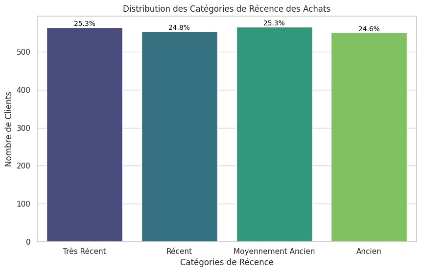

```python
def discretize_recency(value, quartiles):
    if value <= quartiles[0.25]:
        return "Très Récent"
    elif value <= quartiles[0.50]:
        return "Récent"
    elif value <= quartiles[0.75]:
        return "Moyennement Ancien"
    else:
        return "Ancien"

# Calcul des quartiles pour 'Recence_Achat'
quartiles_recency = Data_Campagne['Recence_Achat'].quantile([0.25, 0.50, 0.75])

# Application de la discrétisation
Data_Campagne['Categorie_Recence_Achat'] = Data_Campagne['Recence_Achat'].apply(lambda x: discretize_recency(x, quartiles_recency))

# Utilisation d'un contexte de style Seaborn temporaire pour cette cellule uniquement
with sns.axes_style("whitegrid"):
    # Création de l'histogramme pour 'Categorie_Recence_Achat'
    plt.figure(figsize=(10, 6))
    ax = sns.countplot(x='Categorie_Recence_Achat', data=Data_Campagne, palette='viridis', order=['Très Récent', 'Récent', 'Moyennement Ancien', 'Ancien'])
    ax.set_title('Distribution des Catégories de Récence des Achats')
    ax.set_xlabel('Catégories de Récence')
    ax.set_ylabel('Nombre de Clients')

    # Calcul du total pour les pourcentages
    total = len(Data_Campagne['Categorie_Recence_Achat'])

    # Ajout des pourcentages sur les barres
    for p in ax.patches:
        percentage = '{:.1f}%'.format(100 * p.get_height() / total)
        ax.annotate(percentage, (p.get_x() + p.get_width() / 2., p.get_height()),
                    ha='center', va='center', fontsize=10, color='black',
                    xytext=(0, 5), textcoords='offset points')

    plt.show()
```

### Interprétation des Catégories de Récence des Achats

La discrétisation de la variable 'Recence_Achat' en catégories basées sur le temps écoulé depuis le dernier achat révèle une distribution relativement équilibrée entre les différentes catégories. Voici les points clés :

- **Moyennement Ancien et Très Récent :** Chacune de ces catégories représente environ 25.31% des clients, indiquant une répartition similaire entre les clients ayant effectué un achat récent et ceux dont l'achat est plus ancien.
- **Récent :** Avec 24.78%, cette catégorie est légèrement moins représentée, mais reste proche des autres en termes de proportion.
- **Ancien :** Les clients dans cette catégorie, représentant 24.60%, sont ceux qui n'ont pas effectué d'achats depuis un certain temps.

Cette distribution équilibrée suggère une activité régulière d'achat parmi la clientèle. Les informations obtenues peuvent être utilisées pour cibler des stratégies marketing spécifiques, en se concentrant par exemple sur la réactivation des clients 'Anciens' ou sur le maintien de l'engagement des clients 'Très Récent'.

### Nettoyage de la Base de Données

Dans le cadre de la préparation de notre base de données pour les analyses plus avancées, un nettoyage approfondi a été effectué. Ce processus inclut la suppression de certaines colonnes qui ont été traitées ou qui ne sont plus nécessaires pour les étapes suivantes. Voici les détails :

- **Colonnes Supprimées :** Les variables initiales telles que 'Revenu', 'Age', 'Annee_Naissance', 'Date_Inscription', diverses catégories de dépenses, ainsi que 'Recence_Achat' ont été retirées. La raison principale est que ces variables ont déjà été discrétisées ou transformées, et leurs versions originales ne sont plus nécessaires.
- **Conservation des Données Traitées :** Seules les versions discrétisées ou transformées de ces variables sont conservées pour garantir que notre analyse se base sur des informations pertinentes et simplifiées.

Cette étape de nettoyage vise à alléger la base de données et à se concentrer sur les variables les plus utiles pour notre analyse bivariée et la modélisation ultérieure.

```python
col_drop = ["Identifiant","Revenu", "Age", "Annee_Naissance", "Date_Inscription", 'Depenses_Vins', 'Depenses_Fruits', 'Depenses_Viandes', 'Depenses_Poissons', 'Depenses_Sucreries', 'Depenses_Or', 'Cout_Contact', 'Revenu_Z', 'Recence_Achat']
Data_Campagne_clean = Data_Campagne.drop(col_drop, axis=1)
Data_Campagne_clean
```

|  | Niveau_Education | Statut_Marital | Nb_Enfants | Nb_Adolescents | Achats_Promos | Achats_Web | Achats_Catalogue | Achats_Magasin | VisitesWeb_Mois | Campagne3_Acceptee | ... | Categorie_Revenu | Categorie_Depenses_Vins | Categorie_Depenses_Fruits | Categorie_Depenses_Viandes | Categorie_Depenses_Poissons | Categorie_Depenses_Sucreries | Categorie_Depenses_Or | Anciennete | Categorie_Age | Categorie_Recence_Achat |
| --- | --- | --- | --- | --- | --- | --- | --- | --- | --- | --- | --- | --- | --- | --- | --- | --- | --- | --- | --- | --- | --- |
| 0 | Graduation | Seul/Célibataire | 0 | 0 | 2-4 | 8+ | 8+ | 2-4 | 5-7 | 0 | ... | [51,381.5€_et_68,522€[ | sup_504.25€ | sup_33.0€ | sup_232.0€ | sup_50.0€ | sup_33.0€ | sup_56.0€ | 7 | sup_60_ans | Moyennement Ancien |
| 1 | Graduation | Seul/Célibataire | 1 | 1 | 2-4 | 1 | 1 | 2-4 | 5-7 | 0 | ... | [35,303€_et_51,381.5€[ | inf_23.75€ | inf_1.0€ | inf_16.0€ | inf_3.0€ | inf_1.0€ | inf_9.0€ | 5 | sup_60_ans | Récent |
| 2 | Graduation | Marié/Ensemble | 0 | 0 | 1 | 8+ | 2-4 | 8+ | 2-4 | 0 | ... | sup_68,522€ | [173.5€_et_504.25€[ | sup_33.0€ | [67.0€_et_232.0€[ | sup_50.0€ | [8.0€_et_33.0€[ | [24.0€_et_56.0€[ | 6 | [_49_et_60_ans] | Récent |
| 3 | Graduation | Marié/Ensemble | 1 | 0 | 2-4 | 2-4 | 0 | 2-4 | 5-7 | 0 | ... | inf_35,303€ | inf_23.75€ | [1.0€_et_8.0€[ | [16.0€_et_67.0€[ | [3.0€_et_12.0€[ | [1.0€_et_8.0€[ | inf_9.0€ | 5 | inf_42_ans | Récent |
| 4 | PhD | Marié/Ensemble | 1 | 0 | 5-7 | 5-7 | 2-4 | 5-7 | 5-7 | 0 | ... | [51,381.5€_et_68,522€[ | [23.75€_et_173.5€[ | sup_33.0€ | [67.0€_et_232.0€[ | [12.0€_et_50.0€[ | [8.0€_et_33.0€[ | [9.0€_et_24.0€[ | 5 | inf_42_ans | Ancien |
| ... | ... | ... | ... | ... | ... | ... | ... | ... | ... | ... | ... | ... | ... | ... | ... | ... | ... | ... | ... | ... | ... |
| 2235 | Graduation | Marié/Ensemble | 0 | 1 | 2-4 | 8+ | 2-4 | 2-4 | 5-7 | 0 | ... | [51,381.5€_et_68,522€[ | sup_504.25€ | sup_33.0€ | [67.0€_et_232.0€[ | [12.0€_et_50.0€[ | sup_33.0€ | sup_56.0€ | 6 | [_49_et_60_ans] | Récent |
| 2236 | PhD | Marié/Ensemble | 2 | 1 | 5-7 | 8+ | 2-4 | 5-7 | 5-7 | 0 | ... | [51,381.5€_et_68,522€[ | [173.5€_et_504.25€[ | inf_1.0€ | [16.0€_et_67.0€[ | inf_3.0€ | inf_1.0€ | inf_9.0€ | 5 | sup_60_ans | Moyennement Ancien |
| 2237 | Graduation | Divorcé/Veuve | 0 | 0 | 1 | 2-4 | 2-4 | 8+ | 5-7 | 0 | ... | [51,381.5€_et_68,522€[ | sup_504.25€ | sup_33.0€ | [67.0€_et_232.0€[ | [12.0€_et_50.0€[ | [8.0€_et_33.0€[ | [9.0€_et_24.0€[ | 5 | inf_42_ans | Ancien |
| 2238 | Master | Marié/Ensemble | 0 | 1 | 2-4 | 5-7 | 5-7 | 8+ | 2-4 | 0 | ... | sup_68,522€ | [173.5€_et_504.25€[ | [8.0€_et_33.0€[ | [67.0€_et_232.0€[ | sup_50.0€ | [8.0€_et_33.0€[ | sup_56.0€ | 5 | sup_60_ans | Très Récent |
| 2239 | PhD | Marié/Ensemble | 1 | 1 | 2-4 | 2-4 | 1 | 2-4 | 5-7 | 0 | ... | [51,381.5€_et_68,522€[ | [23.75€_et_173.5€[ | [1.0€_et_8.0€[ | [16.0€_et_67.0€[ | inf_3.0€ | inf_1.0€ | [9.0€_et_24.0€[ | 7 | sup_60_ans | Récent |

2236 rows × 26 columns

# Analyse Bivariée

### 🔍 Analyse Bivariée des Données

Après avoir effectué le prétraitement et la discrétisation de nos données, nous entamons désormais l'étape cruciale de l'analyse bivariée. Cette phase nous permet d'explorer les relations entre différentes paires de variables, offrant des aperçus précieux sur la manière dont ces variables interagissent et influent sur les comportements des clients.

Notre attention se porte particulièrement sur quelques variables clés afin d'explorer leurs relations mutuelles. Cette analyse revêt une importance capitale, permettant de déceler des tendances et des patterns significatifs, fournissant ainsi des indications essentielles pour la compréhension globale des données et la construction de modèles prédictifs efficaces.

D'autre part, cette section nous offre l'opportunité d'étudier les distinctions entre les caractéristiques des clients ayant répondu positivement aux offres de la campagne publicitaire. Comme mentionné précédemment, un volet essentiel de notre projet est axé sur la compréhension des caractéristiques distinguant ces deux groupes d'individus. En effet, l'identification des traits spécifiques chez les personnes ayant manifesté un intérêt pour l'offre dans la campagne revêt une importance significative pour l'entreprise. Cette analyse approfondie pourrait fournir des informations cruciales, optimisant ainsi les stratégies marketing en ciblant plus efficacement les segments de la clientèle les plus réceptifs. Une telle approche contribuerait à accroître l'efficacité des campagnes et à maximiser le taux de conversion.

[figure not shown]

```python
# Variable cible
target = 'Reponse'  # Assurez-vous que 'Reponse' est le nom correct de la colonne cible

# Variables à analyser
variables_to_analyze = [col for col in Data_Campagne_clean.columns if col != target]

# Configuration du style des graphiques
sns.set(style="whitegrid")

# Création des graphiques en boucle
num_graphs_per_row = 2
num_rows = len(variables_to_analyze) // num_graphs_per_row + (len(variables_to_analyze) % num_graphs_per_row > 0)

fig, axes = plt.subplots(num_rows, num_graphs_per_row, figsize=(12, num_rows * 6))
axes = axes.flatten()  # Aplatir le tableau des axes pour un accès facile

for i, var in enumerate(variables_to_analyze):
    ax = axes[i]
    sns.countplot(x=var, hue=target, data=Data_Campagne_clean, palette='viridis', ax=ax)
    ax.set_title(f'Distribution de {target} par {var}')

    # Calculer les proportions pour chaque catégorie
    proportions = Data_Campagne_clean.groupby(var)[target].value_counts(normalize=True).unstack() * 100

    # Annoter les pourcentages sur les barres
    for p in ax.patches:
        height = p.get_height()
        if np.isnan(height):
            continue  # Ignore les barres sans données
        width, x, y = p.get_width(), p.get_xy()[0], p.get_xy()[1]
        cat = p.get_x() + width / 2
        cat_val = ax.get_xticklabels()[int(cat)].get_text()
        total_count = Data_Campagne_clean[Data_Campagne_clean[var] == cat_val][target].count()
        percentage = '{:.1f}%'.format(100 * height / total_count)
        ax.annotate(percentage, (x + width / 2, y + height / 2),
                    ha='center', va='center', fontsize=10, color='black')

# Supprimer les axes vides si nécessaire
for j in range(i+1, num_rows * num_graphs_per_row):
    fig.delaxes(axes[j])

plt.tight_layout()
plt.show()
```

### Interprétation Détaillée des Résultats de l'Analyse Bivariée

Notre analyse bivariée a permis de révéler des relations significatives entre les caractéristiques des clients et leurs réponses aux campagnes marketing.

Les individus avec un doctorat (PhD) présentent le taux de réponse le plus élevé à 20.78%, alors que ceux avec un niveau d'éducation '2n Cycle' ont le taux le plus bas à 10.84%. Cette différence souligne l'importance du niveau d'éducation dans la réceptivité aux campagnes.

Les ménages sans enfants ont un taux de réponse plus élevé (17.17%) par rapport à ceux avec enfants, et une tendance similaire est observée chez les familles sans adolescents. Ces observations suggèrent que la composition familiale peut influencer la réponse aux campagnes.

Pour les achats, notamment promotionnels et sur le web, les clients ayant des volumes d'achats plus élevés tendent à répondre plus positivement aux campagnes. Par exemple, 21.74% des clients avec des achats promotionnels '8+' ont réagi favorablement.

Les réponses aux campagnes antérieures se révèlent être des prédicteurs fiables des réponses futures. En particulier, les clients ayant réagi positivement à la Campagne 5 ont montré un taux de réponse élevé de 56.44% aux campagnes suivantes.

Les clients avec un revenu élevé et des dépenses conséquentes, en particulier en vins, sont plus enclins à répondre aux campagnes, indiquant une corrélation entre le pouvoir d'achat et la réceptivité aux offres.

L'ancienneté et l'âge des clients jouent également un rôle dans leur réponse aux campagnes. Les clients plus anciens et les jeunes adultes montrent un intérêt plus prononcé pour les offres.

La recence des achats est un facteur déterminant, avec une réponse plus forte des clients ayant effectué des achats très récemment.

En conclusion, ces tendances bivariées offrent des indications précieuses pour le ciblage et l'optimisation des stratégies marketing futures.

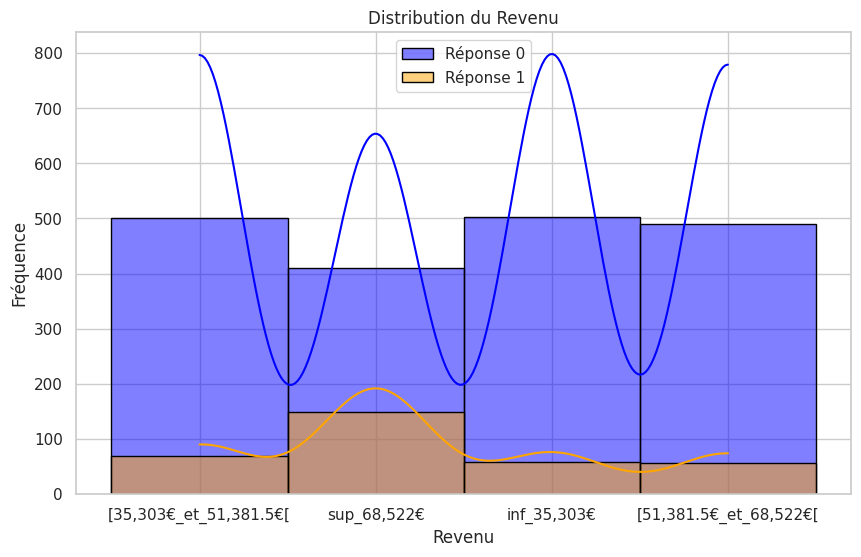

```python
with sns.axes_style("whitegrid"):
    # Création d'un histogramme pour la variable 'Revenu'
    plt.figure(figsize=(10, 6))

    # Tracer l'histogramme pour la modalité 0 (Réponse == 0) en bleu
    sns.histplot(Data_Campagne_clean[Data_Campagne_clean['Reponse'] == 0]['Categorie_Revenu'], kde=True, color='blue', edgecolor='black', label='Réponse 0')

    # Tracer l'histogramme pour la modalité 1 (Réponse == 1) en orange
    sns.histplot(Data_Campagne_clean[Data_Campagne_clean['Reponse'] == 1]['Categorie_Revenu'], kde=True, color='orange', edgecolor='black', label='Réponse 1')

    plt.title('Distribution du Revenu')
    plt.xlabel('Revenu')
    plt.ylabel('Fréquence')
    plt.legend()
    plt.show()
```

### Interprétation revenu par type de reponse

En se penchant sur la variable "revenu", des similarités apparentes entre les deux groupes d'individus se manifestent initialement. Toutefois, une différenciation notable se dégage spécifiquement au sein du groupe de clients démontrant un intérêt. Il est à noter que la distribution des revenus au sein de ce groupe présente deux pics, l'un d'eux devenant plus marqué à mesure que les salaires augmentent. En revanche, pour le second groupe, la concentration des salaires demeure relativement uniforme, se situant principalement autour de la moyenne. Cette observation suggère une corrélation potentielle entre l'intérêt des clients et des niveaux de revenu plus élevés, tandis que le second groupe semble caractérisé par une distribution de revenus plus équilibrée.

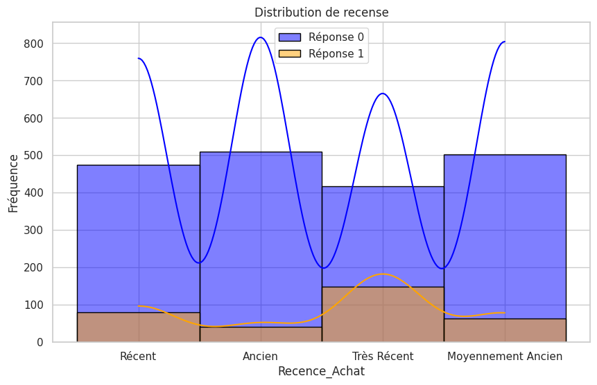

```python
with sns.axes_style("whitegrid"):
    # Création d'un histogramme pour la variable 'Revenu'
    plt.figure(figsize=(10, 6))

    # Tracer l'histogramme pour la modalité 0 (Réponse == 0) en bleu
    sns.histplot(Data_Campagne_clean[Data_Campagne_clean['Reponse'] == 0]['Categorie_Recence_Achat'], kde=True, color='blue', edgecolor='black', label='Réponse 0')

    # Tracer l'histogramme pour la modalité 1 (Réponse == 1) en orange
    sns.histplot(Data_Campagne_clean[Data_Campagne_clean['Reponse'] == 1]['Categorie_Recence_Achat'], kde=True, color='orange', edgecolor='black', label='Réponse 1')

    plt.title('Distribution de recense')
    plt.xlabel('Recence_Achat')
    plt.ylabel('Fréquence')
    plt.legend()
    plt.show()
```

### Interprétation recense par type de reponse

Nous pouvons à présent discerner une disparité dans le comportement des différents clients en examinant la variable "récence d'achat". En effet, ceux ayant manifesté un intérêt pour la campagne présentent une récence d'achat plus faible que ceux qui n'ont exprimé aucun intérêt. Cette observation pourrait potentiellement servir de critère pour évaluer leur intérêt envers la campagne publicitaire. Les individus ayant montré de l'intérêt ont tendance à effectuer des achats de manière plus fréquente, tandis que les autres clients du second groupe ont l'habitude d'attendre plus longtemps avant un nouvel achat. Ainsi, il est plausible de comprendre que leur intérêt pour la campagne publicitaire découle éventuellement du fait qu'ils ont déjà une attitude positive envers la marque.

# 📊 Modélisation et Evaluation

### 📊 Modélisation et Exploration des Données

L'étape de modélisation est cruciale dans notre projet d'analyse des données marketing. Elle consiste à appliquer des techniques statistiques et des algorithmes d'apprentissage automatique pour comprendre en profondeur les tendances et les patterns dans nos données. Cette étape nous permettra d'élaborer des modèles prédictifs efficaces.

L'objectif principal est de prédire comment les clients vont répondre aux campagnes marketing, en se basant sur leurs caractéristiques démographiques, comportementales et d'achat. Les modèles que nous allons développer nous aideront à identifier les facteurs clés qui influencent les décisions des clients et à cibler nos campagnes de manière plus efficace.

- Nous explorerons différents types de modèles pour trouver celui qui offre la meilleure performance.
- Les techniques incluent la régression logistique, les arbres de décision, les forêts aléatoires, et potentiellement des modèles plus complexes comme le boosting et les réseaux de neurones.
- La validation croisée sera utilisée pour assurer que nos modèles sont robustes et généralisables à de nouvelles données.
- Nous accorderons une attention particulière à l'interprétabilité des modèles pour que les insights générés puissent être facilement compris et appliqués par les équipes marketing.

Cette étape de modélisation est essentielle pour transformer nos analyses en actions concrètes et stratégies marketing orientées données. Elle nous permettra d'optimiser nos ressources et de maximiser l'impact de nos campagnes marketing.

```python
Data_Campagne_clean.head()
```

|  | Niveau_Education | Statut_Marital | Nb_Enfants | Nb_Adolescents | Achats_Promos | Achats_Web | Achats_Catalogue | Achats_Magasin | VisitesWeb_Mois | Campagne3_Acceptee | ... | Categorie_Revenu | Categorie_Depenses_Vins | Categorie_Depenses_Fruits | Categorie_Depenses_Viandes | Categorie_Depenses_Poissons | Categorie_Depenses_Sucreries | Categorie_Depenses_Or | Anciennete | Categorie_Age | Categorie_Recence_Achat |
| --- | --- | --- | --- | --- | --- | --- | --- | --- | --- | --- | --- | --- | --- | --- | --- | --- | --- | --- | --- | --- | --- |
| 0 | Graduation | Seul/Célibataire | 0 | 0 | 2-4 | 8+ | 8+ | 2-4 | 5-7 | 0 | ... | [51,381.5€_et_68,522€[ | sup_504.25€ | sup_33.0€ | sup_232.0€ | sup_50.0€ | sup_33.0€ | sup_56.0€ | 7 | sup_60_ans | Moyennement Ancien |
| 1 | Graduation | Seul/Célibataire | 1 | 1 | 2-4 | 1 | 1 | 2-4 | 5-7 | 0 | ... | [35,303€_et_51,381.5€[ | inf_23.75€ | inf_1.0€ | inf_16.0€ | inf_3.0€ | inf_1.0€ | inf_9.0€ | 5 | sup_60_ans | Récent |
| 2 | Graduation | Marié/Ensemble | 0 | 0 | 1 | 8+ | 2-4 | 8+ | 2-4 | 0 | ... | sup_68,522€ | [173.5€_et_504.25€[ | sup_33.0€ | [67.0€_et_232.0€[ | sup_50.0€ | [8.0€_et_33.0€[ | [24.0€_et_56.0€[ | 6 | [_49_et_60_ans] | Récent |
| 3 | Graduation | Marié/Ensemble | 1 | 0 | 2-4 | 2-4 | 0 | 2-4 | 5-7 | 0 | ... | inf_35,303€ | inf_23.75€ | [1.0€_et_8.0€[ | [16.0€_et_67.0€[ | [3.0€_et_12.0€[ | [1.0€_et_8.0€[ | inf_9.0€ | 5 | inf_42_ans | Récent |
| 4 | PhD | Marié/Ensemble | 1 | 0 | 5-7 | 5-7 | 2-4 | 5-7 | 5-7 | 0 | ... | [51,381.5€_et_68,522€[ | [23.75€_et_173.5€[ | sup_33.0€ | [67.0€_et_232.0€[ | [12.0€_et_50.0€[ | [8.0€_et_33.0€[ | [9.0€_et_24.0€[ | 5 | inf_42_ans | Ancien |

5 rows × 26 columns

### Transformation des Variables Catégorielles via le Codage à Chaud (One-Hot Encoding)

Pour préparer les données pour la modélisation, une étape cruciale a été la transformation des variables qualitatives (catégorielles) en utilisant la technique de codage à chaud. Cette méthode consiste à créer des colonnes supplémentaires indiquant la présence (ou l'absence) de chaque catégorie possible dans les données originales.

Voici les étapes clés du processus :

- **Identification des Variables Qualitatives :** Toutes les colonnes de type 'object' ont été sélectionnées pour le codage, car elles représentent des données catégorielles.
- **Application du Codage à Chaud :** Chaque catégorie unique d'une variable catégorielle a été convertie en une nouvelle colonne binaire (0 ou 1) dans le jeu de données.
- **Résultat Final :** Le jeu de données transformé contient maintenant des colonnes supplémentaires, chacune correspondant à une catégorie spécifique des variables originales. Par exemple, pour une variable avec trois catégories, trois nouvelles colonnes sont créées.

Cette transformation est essentielle pour permettre aux modèles de machine learning de traiter efficacement les données catégorielles, et elle a été réalisée en utilisant la bibliothèque scikit-learn de Python.

L'utilisation de cette technique assure que chaque catégorie est représentée comme une entité distincte dans le modèle, permettant ainsi une analyse plus précise et nuancée des données.

```python
# Conversion des colonnes spécifiées en type 'object'
Data_Campagne_clean["Nb_Enfants"] = Data_Campagne_clean["Nb_Enfants"].astype('object')
Data_Campagne_clean["Nb_Adolescents"] = Data_Campagne_clean["Nb_Adolescents"].astype('object')
Data_Campagne_clean["Anciennete"] = Data_Campagne_clean["Anciennete"].astype('object')

# Sélection des colonnes de type 'object' (variables qualitatives)
qualitative_columns = Data_Campagne_clean.select_dtypes(include=['object']).columns

# Application de OneHotEncoder
encoder = OneHotEncoder(sparse=False)
encoded_data = encoder.fit_transform(Data_Campagne_clean[qualitative_columns])

# Création d'un DataFrame avec les données encodées
encoded_column_names = encoder.get_feature_names_out(qualitative_columns)
encoded_df = pd.DataFrame(encoded_data, columns=encoded_column_names)

# Concaténation des données encodées avec les données originales, suppression des colonnes qualitatives originales
# Réinitialisation des indices des DataFrames
Data_Campagne_clean.reset_index(drop=True, inplace=True)
encoded_df.reset_index(drop=True, inplace=True)

transformed_data = pd.concat([Data_Campagne_clean.drop(qualitative_columns, axis=1), encoded_df], axis=1)

# Vérification des valeurs manquantes dans les données transformées
missing_values = transformed_data.isnull().sum()
missing_values[missing_values > 0]  # Affiche uniquement les colonnes avec des valeurs manquantes
```

```
Series([], dtype: int64)
```

### Analyse de Corrélation avec la Variable Cible 'Reponse'

Après la transformation des données, une analyse de corrélation a été effectuée pour identifier les variables les plus influentes sur la variable cible 'Reponse'. Cette étape est essentielle pour comprendre quelles caractéristiques ont le plus d'impact sur la probabilité de réponse des clients aux offres marketing.

Méthodologie utilisée pour l'analyse de corrélation :

- **Calcul des Coefficients de Corrélation :** Les coefficients de corrélation entre la variable cible 'Reponse' et toutes les autres variables ont été calculés. Ces coefficients mesurent la force et la direction de la relation linéaire entre deux variables.
- **Sélection des Variables les Plus Corrélées :** Les 40 variables présentant la plus forte corrélation (positive ou négative) avec 'Reponse' ont été sélectionnées pour un examen plus approfondi.
- **Visualisation des Résultats :** Un graphique en barres a été créé pour visualiser ces relations de corrélation, facilitant ainsi l'identification des variables les plus significatives.

L'analyse a révélé des insights précieux sur les facteurs influençant la décision des clients, permettant d'affiner davantage les stratégies marketing et les campagnes ciblées.

[figure not shown]

```python
import matplotlib.pyplot as plt
import seaborn as sns

# Calcul de la corrélation avec la variable cible 'Reponse'
correlation = transformed_data.corr()['Reponse'].sort_values(ascending=False)

# Sélection des 10 variables les plus positivement corrélées et 10 les plus négativement corrélées
# Exclure 'Reponse' elle-même en ne prenant pas la première corrélation
top_positive_correlated = correlation[1:21]  # 10 plus positives
top_negative_correlated = correlation[-20:]  # 10 plus négatives

# Combiner les deux séries pour le graphique
top_correlated_columns = pd.concat([top_positive_correlated, top_negative_correlated])

# Création d'un graphique en barres pour la visualisation
plt.figure(figsize=(12, 10))
sns.barplot(x=top_correlated_columns.values, y=top_correlated_columns.index, palette="viridis")

plt.title('Top 10 Positive and Negative Correlations with "Reponse"', fontsize=15)
plt.xlabel('Correlation Coefficient')
plt.ylabel('Variables')
plt.grid(True)
plt.show()
```

### Interprétation des Variables Clés Corrélées avec 'Reponse'

L'analyse des corrélations avec 'Reponse' souligne des éléments décisifs pour les succès des campagnes marketing. Les données mettent en avant l'influence de l'historique des réponses aux campagnes, les niveaux de dépenses, les catégories de revenus, la récence des achats, et le statut marital.

- **Historique des Campagnes :** La propension à répondre positivement est fortement liée à l'acceptation de campagnes antérieures, indiquant que les expériences passées sont prédictives des comportements futurs.
- **Dépenses en Viandes et Vins :** Des dépenses supérieures dans les catégories des viandes et des vins signalent une tendance à une réponse positive, ce qui pourrait indiquer un mode de vie plus opulent ou une préférence pour ces produits.
- **Revenu Élevé :** Les individus dans la tranche de revenu la plus haute sont plus enclins à répondre, suggérant l'efficacité de cibler les offres premium vers ce segment.
- **Récence d'Achat :** Une récence d'achat "Très Récent" est associée à une plus grande ouverture aux campagnes, ce qui souligne l'opportunité de cibler les clients peu après un achat.
- **Statut Marital et Nombre d'Adolescents :** Être célibataire ou ne pas avoir d'adolescents est prédictif d'une réponse positive, soulignant le potentiel de cibler ces groupes démographiques spécifiques.

D'un autre côté, les dépenses modestes dans certaines catégories, un revenu inférieur, et un statut marital de marié ou en couple sont associés à une moindre probabilité de réponse. De plus, les clients avec au moins un adolescent et ceux avec une ancienneté de 5 ans tendent à être moins réceptifs aux campagnes.

Ces aperçus suggèrent que des campagnes ciblées sur les clients ayant des interactions positives antérieures et sur ceux avec un niveau de vie plus élevé pourraient être plus efficaces. Parallèlement, il est conseillé de reconsidérer ou d'adapter les stratégies pour les segments moins engagés. Ces corrélations, bien qu'indicatives, ne doivent pas être interprétées comme des causes directes sans analyses supplémentaires telles que des tests A/B.

Cette analyse enrichit notre stratégie marketing, en mettant en lumière les caractéristiques des clients susceptibles de répondre favorablement. L'accent mis sur une approche basée sur les données promet non seulement d'améliorer les taux de réponse, mais aussi de renforcer la fidélisation de la clientèle et d'optimiser le retour sur investissement.

### Division du Jeu de Données en Ensembles d'Entraînement et de Test

Une étape cruciale dans la préparation des données pour le modèle de machine learning est de diviser le jeu de données en ensembles d'entraînement et de test. Cette division est essentielle pour évaluer la performance du modèle de manière fiable et impartiale.

Pour notre analyse, une attention particulière est accordée à la répartition de la variable cible 'Reponse' dans les ensembles d'entraînement et de test. Il est important que cette variable soit équilibrée dans les deux ensembles pour éviter tout biais dans l'apprentissage du modèle et dans l'évaluation de ses performances.

- **Stratification :** La stratification garantit que la proportion de la variable cible 'Reponse' est similaire dans les ensembles d'entraînement et de test. Cela est particulièrement important si la variable cible est déséquilibrée (par exemple, si une classe est beaucoup plus fréquente que l'autre).
- **Taille des Ensembles :** Généralement, le jeu de données est divisé en 70-80% pour l'entraînement et 20-30% pour le test, mais cela peut varier en fonction de la taille et de la spécificité des données.

En suivant cette approche, nous nous assurons que le modèle est entraîné et testé sur des données représentatives, augmentant ainsi la fiabilité et la validité de nos résultats.

```python
X = transformed_data.drop('Reponse', axis=1)  # Caractéristiques
y = transformed_data['Reponse']               # Cible

# Division des données en ensembles d'entraînement et de test, avec stratification
X_train, X_test, y_train, y_test = train_test_split(X, y, test_size=0.3, random_state=42, stratify=y)

# Pour vérifier, vous pouvez regarder les proportions de 'Reponse' dans les ensembles d'entraînement et de test
train_proportion = y_train.value_counts(normalize=True)*100
test_proportion = y_test.value_counts(normalize=True)*100
print(train_proportion)
print(test_proportion)
```

```
Reponse
0    85.175719
1    14.824281
Name: proportion, dtype: float64
Reponse
0    85.09687
1    14.90313
Name: proportion, dtype: float64
```

# REGRESSION LOGISTIQUE

### Introduction à la Régression Logistique pour l'Analyse des Campagnes Marketing

La régression logistique est un outil statistique puissant utilisé pour modéliser la probabilité d'un événement binaire ou catégoriel. Dans le cadre de notre projet, ce modèle sera utilisé pour prédire la probabilité de réponse d'un client à une campagne marketing (réponse ou non-réponse).

**Contexte du Modèle :** La régression logistique est particulièrement adaptée à notre analyse car elle permet de traiter des problèmes de classification binaire, où l'objectif est de prédire une variable dépendante binaire (dans notre cas, la 'Reponse' du client).

**Équation Mathématique :** Le modèle s'articule autour de l'équation logistique, donnée par :  
*P(Y=1) = 1 / (1 + e<sup>-(β<sub>0</sub> + β<sub>1</sub>X<sub>1</sub> + ... + β<sub>k</sub>X<sub>k</sub>)</sup>)*  
où P(Y=1) est la probabilité que la variable dépendante (réponse du client) soit égale à 1, β<sub>i</sub> représente les coefficients du modèle, et X<sub>i</sub> sont les variables explicatives.

**Approche Modélisatrice :** Dans notre projet, nous adoptons une approche progressive, en commençant par des modèles plus simples comme la régression logistique. Cette méthode nous permet de comprendre les relations fondamentales dans les données avant de passer à des modèles plus complexes. Cela facilite également l'interprétation des résultats et la détermination des variables clés influençant la réponse des clients.

L'utilisation de la régression logistique comme point de départ offre un équilibre entre simplicité et puissance prédictive, permettant une première exploration efficace des données et des tendances sous-jacentes.

# **Modèle 1 : Régression Logistique Simple**

```
0.8941877794336811
[[550  21]
 [ 50  50]]
              precision    recall  f1-score   support

           0       0.92      0.96      0.94       571
           1       0.70      0.50      0.58       100

    accuracy                           0.89       671
   macro avg       0.81      0.73      0.76       671
weighted avg       0.89      0.89      0.89       671
```

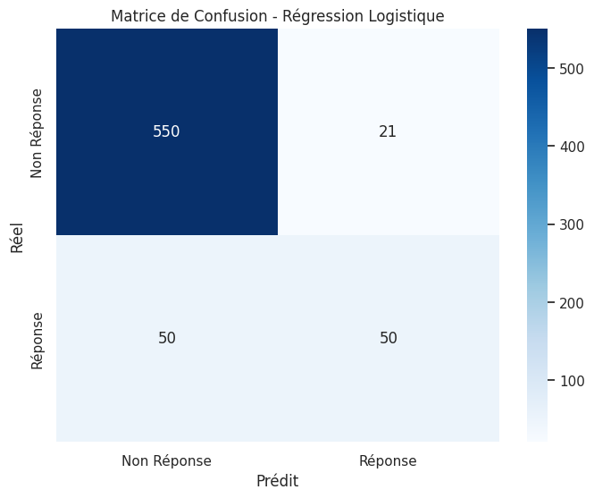

```python
# Création du modèle de régression logistique
logistic_model = LogisticRegression(max_iter=1000, random_state=42)

# Entraînement du modèle avec l'ensemble d'entraînement
logistic_model.fit(X_train, y_train)

# Prédiction sur l'ensemble de test
y_pred = logistic_model.predict(X_test)

# Évaluation du modèle
accuracy = accuracy_score(y_test, y_pred)
conf_matrix = confusion_matrix(y_test, y_pred)
class_report = classification_report(y_test, y_pred)

print(accuracy)
print(conf_matrix)
print(class_report)

# Création d'un heatmap pour la matrice de confusion
plt.figure(figsize=(8, 6))
sns.heatmap(conf_matrix, annot=True, fmt='d', cmap='Blues', xticklabels=['Non Réponse', 'Réponse'], yticklabels=['Non Réponse', 'Réponse'])
plt.title('Matrice de Confusion - Régression Logistique')
plt.xlabel('Prédit')
plt.ylabel('Réel')
plt.show()
```

### Commentaire sur les Résultats du Modèle de Régression Logistique

Le modèle de régression logistique a atteint une précision globale de 89.4%, ce qui semble prometteur à première vue. Cependant, l'analyse des métriques de classification révèle une performance asymétrique entre les classes. Pour la classe majoritaire (0), nous observons une précision élevée et un rappel satisfaisant. En revanche, pour la classe minoritaire (1), le rappel et la précision sont significativement plus faibles, indiquant une difficulté du modèle à identifier correctement les cas positifs.

Ce déséquilibre dans la performance suggère que le modèle pourrait être biaisé en faveur de la classe majoritaire, un phénomène courant lorsque les données d'entraînement présentent un déséquilibre de classe. Pour remédier à cela, il est crucial d'utiliser le paramètre `class_weight` lors de l'entraînement du modèle. Ceci permettra d'attribuer un poids plus important à la classe minoritaire et de pénaliser le modèle pour les erreurs commises sur cette classe, menant ainsi à un équilibre plus juste entre les classes et une amélioration des métriques pour la classe minoritaire.

Ajuster le modèle pour tenir compte du déséquilibre des classes est une étape essentielle pour améliorer la capacité du modèle à généraliser et à être juste envers toutes les catégories de réponse. Cela est particulièrement important dans des contextes où la détection de la classe minoritaire est critique.

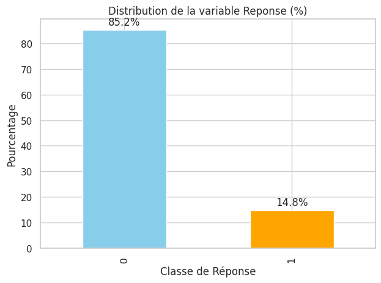

```python
# Calcul des pourcentages pour chaque classe
value_counts = Data_Campagne_clean['Reponse'].value_counts(normalize=True) * 100

# Choisissez une palette de couleurs ou spécifiez les couleurs manuellement
colors = ['skyblue', 'orange']  # Ajoutez plus de couleurs si vous avez plus de classes

# Création de l'histogramme avec des couleurs spécifiées
ax = value_counts.plot(kind='bar', color=colors)
ax.set_title('Distribution de la variable Reponse (%)')
ax.set_xlabel('Classe de Réponse')
ax.set_ylabel('Pourcentage')

# Affichage des pourcentages sur les barres
for i in ax.patches:
    ax.text(i.get_x() + i.get_width() / 2, i.get_height() + 1, f'{i.get_height():.1f}%', ha='center', va='bottom')

plt.tight_layout()
plt.show()
```

# **Modèle 2 : Régression Logistique avec ajustement pour le déséquilibre des classes et optimisation des hyperparamètres**

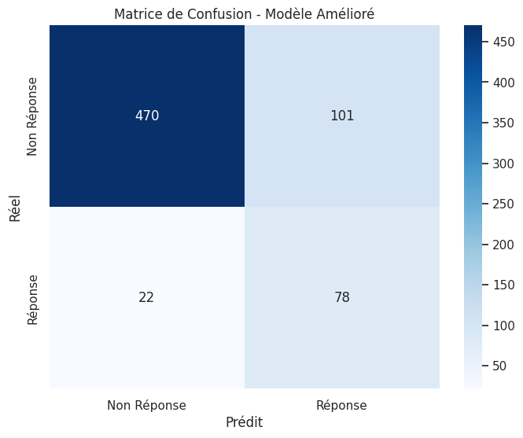

```
0.8166915052160953
              precision    recall  f1-score   support

           0       0.96      0.82      0.88       571
           1       0.44      0.78      0.56       100

    accuracy                           0.82       671
   macro avg       0.70      0.80      0.72       671
weighted avg       0.88      0.82      0.84       671
```

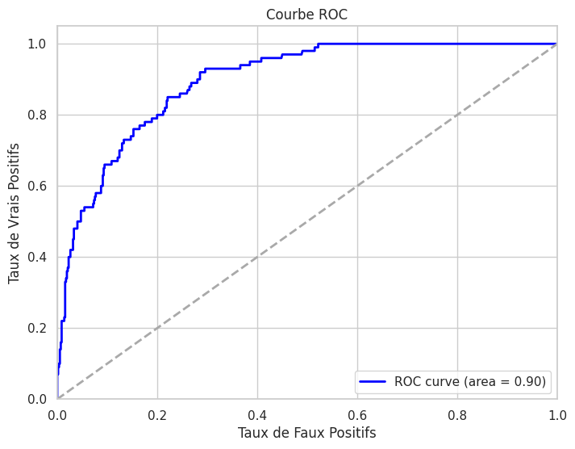

```python
# Définition des hyperparamètres pour la recherche en grille
param_grid = {
    'C': [0.01, 0.1, 1, 10, 100],  # Valeurs de régularisation
    'solver': ['lbfgs', 'liblinear']  # Solveurs
}

# Création du modèle de régression logistique pour la recherche en grille
logistic_model_grid = LogisticRegression(random_state=42, max_iter=1000, class_weight='balanced')

# Recherche en grille avec validation croisée
grid_search = GridSearchCV(logistic_model_grid, param_grid, cv=5, scoring='accuracy')
grid_search.fit(X_train, y_train)

# Meilleurs paramètres
best_params = grid_search.best_params_

# Réentraînement du modèle avec les meilleurs hyperparamètres
best_model = grid_search.best_estimator_
best_model.fit(X_train, y_train)

# Prédiction et évaluation sur l'ensemble de test
y_pred_best = best_model.predict(X_test)
accuracy_best = accuracy_score(y_test, y_pred_best)
conf_matrix_best = confusion_matrix(y_test, y_pred_best)
class_report_best = classification_report(y_test, y_pred_best)

# Affichage des résultats
best_params, accuracy_best, conf_matrix_best, class_report_best

# Génération de la matrice de confusion améliorée
plt.figure(figsize=(8, 6))
sns.heatmap(conf_matrix_best, annot=True, fmt='d', cmap='Blues', xticklabels=['Non Réponse', 'Réponse'], yticklabels=['Non Réponse', 'Réponse'])
plt.title('Matrice de Confusion - Modèle Amélioré')
plt.xlabel('Prédit')
plt.ylabel('Réel')
plt.show()
print(accuracy_best)

print(class_report_best)



# Prédiction des probabilités pour la classe positive
y_proba_best = best_model.predict_proba(X_test)[:, 1]

# Calcul des taux de vrais positifs et de faux positifs
fpr, tpr, thresholds = roc_curve(y_test, y_proba_best)

# Calcul de l'AUC
auc_score = roc_auc_score(y_test, y_proba_best)

# Tracé de la courbe ROC
plt.figure(figsize=(8, 6))
plt.plot(fpr, tpr, color='blue', lw=2, label=f'ROC curve (area = {auc_score:.2f})')
plt.plot([0, 1], [0, 1], color='darkgrey', lw=2, linestyle='--')
plt.xlim([0.0, 1.0])
plt.ylim([0.0, 1.05])
plt.xlabel('Taux de Faux Positifs')
plt.ylabel('Taux de Vrais Positifs')
plt.title('Courbe ROC')
plt.legend(loc='lower right')
plt.show()
```

### Analyse des Résultats du Modèle de Régression Logistique avec Classes Pondérées

Après avoir ajusté les poids des classes dans notre modèle de régression logistique pour tenir compte du déséquilibre de classe, une amélioration significative des métriques de performance pour la classe minoritaire a été observée. Cette approche a permis de porter le rappel de la classe minoritaire à 78%, démontrant une sensibilité accrue du modèle à détecter les réponses positives.

Bien que la précision pour la classe minoritaire reste relativement basse à 44%, l'augmentation substantielle du rappel indique que le modèle est maintenant mieux équipé pour identifier les clients potentiels. Cela peut être particulièrement avantageux dans des contextes où capter chaque opportunité de conversion est crucial, même au risque d'augmenter le nombre de faux positifs.

Les résultats illustrent l'importance d'un réglage minutieux des paramètres du modèle dans des situations de déséquilibre de classe. Les entreprises doivent évaluer l'équilibre entre la précision et le rappel en fonction de leurs objectifs spécifiques et des coûts associés aux erreurs de classification dans chaque classe.

En conclusion, l'ajustement des poids des classes représente une avancée significative dans la modélisation des données déséquilibrées. Il permet d'atteindre une compréhension plus nuancée de la performance du modèle, favorisant des décisions éclairées pour des campagnes marketing plus efficaces et inclusives.

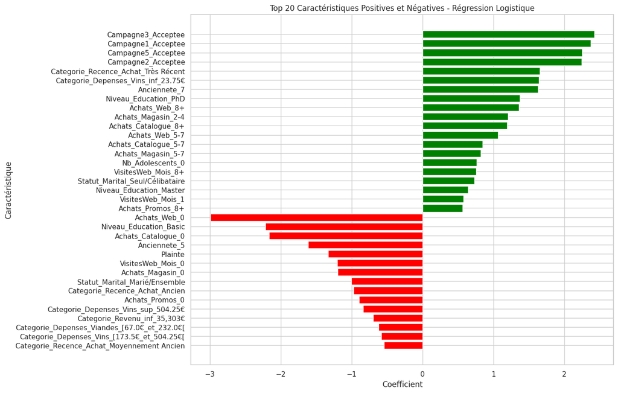

```python
coefficients = best_model.coef_[0]
feature_names = X.columns

# Création du DataFrame
feature_importance = pd.DataFrame({'Feature': feature_names, 'Coefficient': coefficients})

# Sélection des 10 caractéristiques avec les coefficients positifs les plus élevés
top_positive_features = feature_importance[feature_importance['Coefficient'] > 0].sort_values(by='Coefficient', ascending=False).head(20)

# Sélection des 10 caractéristiques avec les coefficients négatifs les plus élevés (en valeur absolue)
top_negative_features = feature_importance[feature_importance['Coefficient'] < 0].sort_values(by='Coefficient').head(15)

# Concaténation des deux listes
top_features = pd.concat([top_positive_features, top_negative_features])

# Couleurs pour les barres: vert pour positif, rouge pour négatif
colors = ['green' if x > 0 else 'red' for x in top_features['Coefficient']]

# Affichage sous forme de graphique à barres horizontales
plt.figure(figsize=(12, 10))
plt.barh(top_features['Feature'], top_features['Coefficient'], color=colors)
plt.xlabel('Coefficient')
plt.ylabel('Caractéristique')
plt.title('Top 20 Caractéristiques Positives et Négatives - Régression Logistique')
plt.gca().invert_yaxis()  # Inverser l'axe Y pour afficher la caractéristique la plus importante en haut
plt.show()
```

### Analyse et Interprétation des Coefficients du Modèle de Régression Logistique

Dans notre modèle de régression logistique, chaque variable explicative se voit attribuer un coefficient qui révèle son influence sur la probabilité d'une "Réponse". Voici les étapes clés de notre analyse :

1. **Extraction des Coefficients :** Nous avons extrait les coefficients pour déterminer comment chaque caractéristique influence la log-odds de la classe cible.
2. **Interprétation des Coefficients :**
   - Un *coefficient positif* indique qu'une augmentation de la valeur de la caractéristique est associée à une augmentation de la probabilité d'une réponse positive.
   - Un *coefficient négatif* suggère qu'une augmentation de la valeur de la caractéristique est liée à une diminution de la probabilité d'une réponse positive.
3. **Approche pour la Significativité des Coefficients :** Bien que la significativité des coefficients ne soit pas directement disponible via scikit-learn, elle peut théoriquement être évaluée à l'aide de techniques statistiques avancées telles que les intervalles de confiance et les tests statistiques (comme le test Wald) en utilisant des bibliothèques comme `statsmodels`. Cependant, nous nous concentrons principalement sur l'interprétation des coefficients dans notre analyse.

L'interprétation des coefficients est essentielle pour comprendre les dynamiques de notre modèle, mais il est important de noter que ces interprétations dépendent de la mise à l'échelle des caractéristiques. L'analyse doit être complétée par une expertise du domaine pour des conclusions pertinentes.

# Interprétation des Coefficients de la Régression Logistique

L'analyse des coefficients de notre modèle de régression logistique révèle des insights clés sur les facteurs influençant les réponses positives dans nos campagnes marketing. Les variables avec des coefficients positifs élevés sont des indicateurs forts de probabilité accrue de réponse positive, tandis que celles avec des coefficients négatifs élevés indiquent une probabilité réduite.

Ces résultats soulignent l'importance de la personnalisation des campagnes basée sur l'historique des interactions des clients et leurs comportements d'achat. L'identification de ces facteurs clés nous permet de cibler plus efficacement nos campagnes, augmentant ainsi les chances de succès.

En résumé, ce modèle nous fournit une compréhension approfondie des dynamiques de réponses des clients, ce qui est essentiel pour optimiser nos stratégies de marketing et maximiser l'engagement des clients.

```python
coefficients = best_model.coef_[0]
feature_names = X_train.columns
coeff_df = pd.DataFrame({'Feature': feature_names, 'Coefficient': coefficients})
# Sélectionner les 20 caractéristiques les plus importantes en valeur absolue
top_20_features = coeff_df.copy()
top_20_features['Absolute_Coefficient'] = abs(top_20_features['Coefficient'])
top_20_features = top_20_features.sort_values(by='Absolute_Coefficient', ascending=False).head(20)
top_20_features
```

|  | Feature | Coefficient | Absolute_Coefficient |
| --- | --- | --- | --- |
| 25 | Achats_Web_0 | -2.994058 | 2.994058 |
| 0 | Campagne3_Acceptee | 2.423612 | 2.423612 |
| 3 | Campagne1_Acceptee | 2.373022 | 2.373022 |
| 2 | Campagne5_Acceptee | 2.250091 | 2.250091 |
| 4 | Campagne2_Acceptee | 2.242715 | 2.242715 |
| 7 | Niveau_Education_Basic | -2.217512 | 2.217512 |
| 30 | Achats_Catalogue_0 | -2.166545 | 2.166545 |
| 83 | Categorie_Recence_Achat_Très Récent | 1.652342 | 1.652342 |
| 51 | Categorie_Depenses_Vins_inf_23.75€ | 1.642287 | 1.642287 |
| 75 | Anciennete_7 | 1.625692 | 1.625692 |
| 73 | Anciennete_5 | -1.615505 | 1.615505 |
| 10 | Niveau_Education_PhD | 1.369555 | 1.369555 |
| 29 | Achats_Web_8+ | 1.360422 | 1.360422 |
| 5 | Plainte | -1.331895 | 1.331895 |
| 37 | Achats_Magasin_2-4 | 1.203857 | 1.203857 |
| 40 | VisitesWeb_Mois_0 | -1.201207 | 1.201207 |
| 35 | Achats_Magasin_0 | -1.198800 | 1.198800 |
| 34 | Achats_Catalogue_8+ | 1.190520 | 1.190520 |
| 28 | Achats_Web_5-7 | 1.061395 | 1.061395 |
| 12 | Statut_Marital_Marié/Ensemble | -1.003944 | 1.003944 |

# **Modèle 3 : Régression Logistique avec ajustement pour le déséquilibre des classes, optimisation des hyperparamètres et suréchantillonnage SMOTE**

### Synthèse des Améliorations Apportées au Modèle de Classification

Afin d'améliorer notre modèle de régression logistique face à un jeu de données présentant un déséquilibre de classes, nous avons déployé une série de techniques avancées d'analyse de données et de machine learning. Le processus d'optimisation a inclus l'utilisation de l'algorithme SMOTE pour le suréchantillonnage de la classe minoritaire, l'application de la standardisation des données pour normaliser les échelles des caractéristiques, et l'emploi d'une recherche aléatoire d'hyperparamètres avec validation croisée stratifiée pour affiner notre modèle.

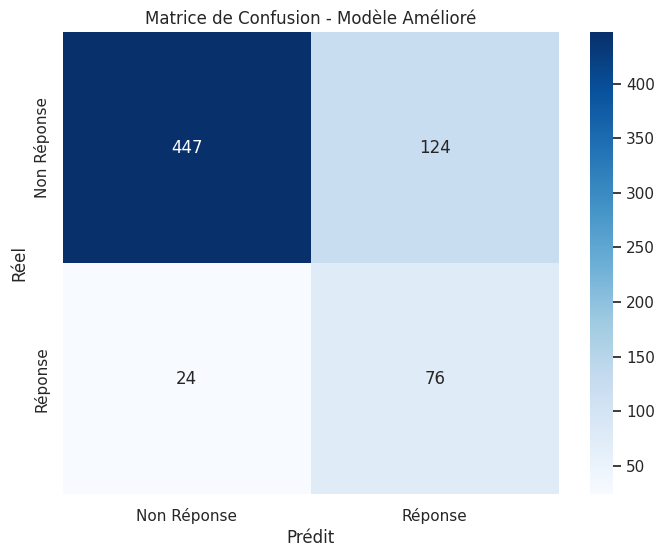

```
0.7794336810730254
              precision    recall  f1-score   support

           0       0.95      0.78      0.86       571
           1       0.38      0.76      0.51       100

    accuracy                           0.78       671
   macro avg       0.66      0.77      0.68       671
weighted avg       0.86      0.78      0.81       671

0.8795183887915937
```

```python
# Configuration du pipeline avec suréchantillonnage SMOTE et standardisation
pipeline = ImbPipeline([
    ('smote', SMOTE(random_state=42)),
    ('scaler', StandardScaler()),
    ('classifier', LogisticRegression(random_state=42, max_iter=1000))
])

# Grille d'hyperparamètres pour RandomizedSearchCV
param_distributions = {
    'classifier__C': [0.01, 0.1, 1, 10, 100],
    'classifier__solver': ['lbfgs', 'liblinear'],
    'classifier__class_weight': [None, 'balanced']
}

# Configuration de RandomizedSearchCV avec validation croisée stratifiée
random_search = RandomizedSearchCV(
    pipeline,
    param_distributions=param_distributions,
    n_iter=20,  # Nombre d'itérations
    cv=StratifiedKFold(n_splits=5),  # Validation croisée stratifiée
    scoring='roc_auc',  # Utilisation de AUC-ROC comme métrique d'évaluation
    random_state=42
)

# Entraînement et recherche des meilleurs hyperparamètres
random_search.fit(X_train, y_train)

# Récupération du meilleur modèle
best_model = random_search.best_estimator_

# Prédiction sur l'ensemble de test
y_pred_best = best_model.predict(X_test)
y_proba_best = best_model.predict_proba(X_test)[:, 1]

# Évaluation du modèle
accuracy_best = accuracy_score(y_test, y_pred_best)
conf_matrix_best = confusion_matrix(y_test, y_pred_best)
class_report_best = classification_report(y_test, y_pred_best)
auc_score_best = roc_auc_score(y_test, y_proba_best)

# Affichage des résultats
best_params = random_search.best_params_
best_params,

plt.figure(figsize=(8, 6))
sns.heatmap(conf_matrix_best, annot=True, fmt='d', cmap='Blues', xticklabels=['Non Réponse', 'Réponse'], yticklabels=['Non Réponse', 'Réponse'])
plt.title('Matrice de Confusion - Modèle Amélioré')
plt.xlabel('Prédit')
plt.ylabel('Réel')
plt.show()
print(accuracy_best)
print(class_report_best)
print(auc_score_best)
```

### Conclusion sur la Sélection du Modèle de Classification

Après avoir examiné et comparé les performances des deux modèles de régression logistique, nous avons décidé de retenir le modèle précédent. Bien que le dernier modèle ait montré une certaine efficacité, notamment en termes de score AUC-ROC, il n'a pas surpassé le modèle précédent en ce qui concerne les mesures cruciales telles que la précision, le rappel et le score F1 pour la classe minoritaire.

Le modèle précédent, avec une précision globale de 82% et un meilleur équilibre entre précision et rappel pour les deux classes, s'est avéré plus adéquat pour nos besoins. Il a réussi à maintenir un taux élevé de détection des cas positifs (classe minoritaire) tout en conservant une bonne performance sur la classe majoritaire.

Cette décision souligne l'importance de l'évaluation globale des modèles, en tenant compte non seulement de la précision globale, mais aussi des performances spécifiques à chaque classe, particulièrement dans les contextes de classes déséquilibrées. Notre choix final reflète notre objectif de créer un modèle équilibré, capable de détecter efficacement les réponses positives tout en minimisant les fausses alertes.

En gardant le modèle précédent, nous nous appuyons sur une approche qui offre un compromis optimal entre sensibilité et spécificité, alignée avec nos objectifs stratégiques de classification précise et pertinente.

# Modèles Challengers

Dans cette section, nous explorons et comparons divers modèles de machine learning pour évaluer leur performance par rapport à notre modèle optimisé de régression logistique, désigné comme le Modèle 2. Cette démarche vise à identifier le modèle le plus efficace pour notre analyse de campagne marketing. Les modèles challengers que nous étudions sont :

- **Arbre de Décision :** Ce modèle simple, basé sur une structure d'arbre, effectue des décisions séquentielles sur les données. Il sera intéressant d'observer comment ce modèle basique se comporte en comparaison avec des approches plus complexes.
- **Random Forest :** En tant que méthode d'ensemble, ce modèle combine les prédictions de plusieurs arbres de décision pour améliorer la fiabilité et la précision. Son comportement face à notre jeu de données fournira des insights sur l'efficacité des méthodes d'ensemble pour notre problème spécifique.
- **Gradient Boosting :** Ce modèle, qui construit des arbres de décision de manière séquentielle, en corrigeant les erreurs des prédécesseurs, offre une perspective différente sur l'approche d'ensemble. Son analyse révélera sa capacité à améliorer progressivement les prédictions.

L'objectif est de comparer ces modèles en termes de précision, de rappel et d'autres métriques pertinentes pour déterminer lequel offre la meilleure performance pour notre cas d'utilisation. Cette analyse comparative nous aidera à sélectionner le modèle le plus adapté à nos besoins de prédiction dans le cadre des campagnes marketing.

# *Arbre de décision*

```
Meilleurs paramètres: {'max_depth': 15, 'min_samples_leaf': 1, 'min_samples_split': 2}
Matrice de confusion:
 [[518  53]
 [ 54  46]]
Rapport de classification:
               precision    recall  f1-score   support

           0       0.91      0.91      0.91       571
           1       0.46      0.46      0.46       100

    accuracy                           0.84       671
   macro avg       0.69      0.68      0.68       671
weighted avg       0.84      0.84      0.84       671

AUC-ROC: 0.6848861646234676
```

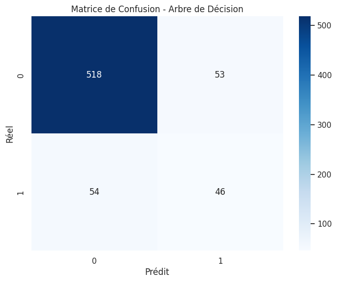

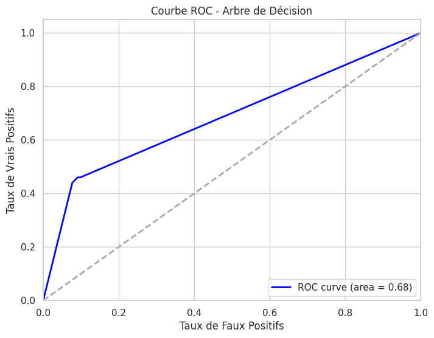

```python
# Configuration du modèle d'arbre de décision
decision_tree_model = DecisionTreeClassifier(random_state=42, class_weight='balanced')

# Grille d'hyperparamètres
param_grid = {
    'max_depth': [10, 15, 20],
    'min_samples_split': [2, 5, 10],
    'min_samples_leaf': [1, 2, 4]
}

# Recherche des meilleurs hyperparamètres
grid_search = GridSearchCV(decision_tree_model, param_grid, cv=5, scoring='accuracy')
grid_search.fit(X_train, y_train)

# Meilleur modèle
best_tree_model = grid_search.best_estimator_

# Prédiction sur l'ensemble de test
y_pred_tree = best_tree_model.predict(X_test)
y_proba_tree = best_tree_model.predict_proba(X_test)[:, 1]

# Évaluation du modèle
conf_matrix_tree = confusion_matrix(y_test, y_pred_tree)
class_report_tree = classification_report(y_test, y_pred_tree)
auc_score_tree = roc_auc_score(y_test, y_proba_tree)

# Affichage des résultats
print("Meilleurs paramètres:", grid_search.best_params_)
print("Matrice de confusion:\n", conf_matrix_tree)
print("Rapport de classification:\n", class_report_tree)
print("AUC-ROC:", auc_score_tree)

# Visualisation de la matrice de confusion
plt.figure(figsize=(8, 6))
sns.heatmap(conf_matrix_tree, annot=True, fmt='d', cmap='Blues')
plt.title('Matrice de Confusion - Arbre de Décision')
plt.xlabel('Prédit')
plt.ylabel('Réel')
plt.show()

# Tracé de la courbe ROC
fpr, tpr, _ = roc_curve(y_test, y_proba_tree)
plt.figure(figsize=(8, 6))
plt.plot(fpr, tpr, color='blue', lw=2, label=f'ROC curve (area = {auc_score_tree:.2f})')
plt.plot([0, 1], [0, 1], color='darkgrey', lw=2, linestyle='--')
plt.xlim([0.0, 1.0])
plt.ylim([0.0, 1.05])
plt.xlabel('Taux de Faux Positifs')
plt.ylabel('Taux de Vrais Positifs')
plt.title('Courbe ROC - Arbre de Décision')
plt.legend(loc='lower right')
plt.show()
```

### Interprétation des Résultats du Modèle d'Arbre de Décision

Les résultats obtenus avec le modèle d'arbre de décision optimisé révèlent certains points clés concernant sa performance comparée à celle du modèle de régression logistique optimisé (Modèle 2). Les paramètres optimaux pour l'arbre de décision sont : profondeur maximale de 15, un minimum d'échantillons par feuille de 1, et un minimum d'échantillons pour diviser de 2.

La matrice de confusion montre que, pour la classe majoritaire (0), le modèle a une bonne précision et un bon rappel, avec 518 vrais positifs sur 571. Cependant, pour la classe minoritaire (1) qui est notre objectif principal, le modèle n'a identifié correctement que 46 cas sur 100, révélant une précision et un rappel équilibrés mais modérés de 46%.

En comparaison, le Modèle 2 de régression logistique avait un score AUC-ROC de 0.90, nettement supérieur aux 0.68 obtenus par l'arbre de décision. Cela suggère que, bien que l'arbre de décision ait une performance acceptable, il est moins efficace que le modèle de régression logistique pour distinguer entre les réponses positives et négatives dans notre contexte de campagne marketing.

En conclusion, bien que l'arbre de décision fournisse des insights utiles, le modèle de régression logistique reste notre choix préféré, en particulier pour notre objectif de maximiser les réponses positives. Son score AUC-ROC plus élevé et sa meilleure distinction entre les classes en font un outil plus robuste pour notre analyse.

# *Randoù Forest*

```
Meilleurs paramètres: {'max_depth': 15, 'min_samples_leaf': 2, 'min_samples_split': 5, 'n_estimators': 100}
Matrice de confusion:
 [[549  22]
 [ 51  49]]
Rapport de classification:
               precision    recall  f1-score   support

           0       0.92      0.96      0.94       571
           1       0.69      0.49      0.57       100

    accuracy                           0.89       671
   macro avg       0.80      0.73      0.76       671
weighted avg       0.88      0.89      0.88       671

AUC-ROC: 0.8908318739054291
```

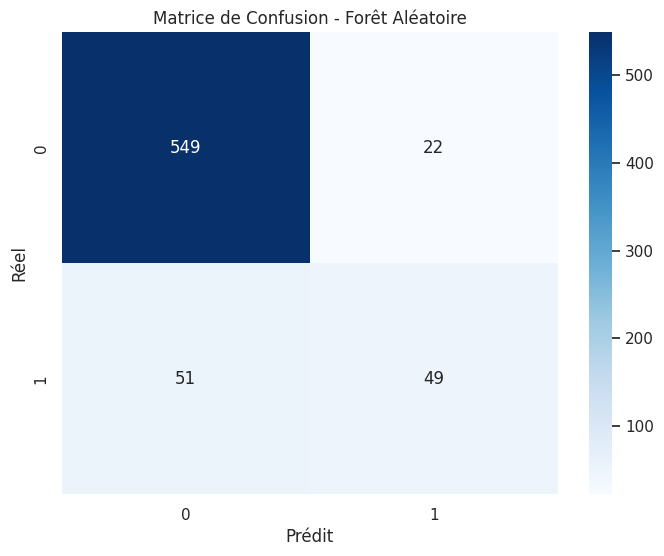

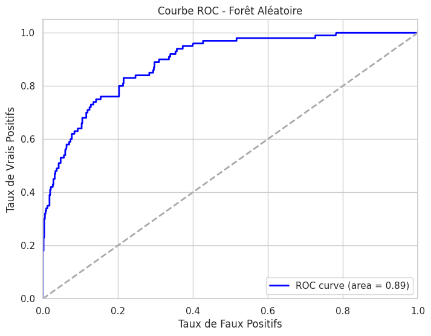

```python
# Configuration du modèle de forêt aléatoire
random_forest_model = RandomForestClassifier(random_state=42, class_weight='balanced')

# Grille d'hyperparamètres
param_grid = {
    'n_estimators': [100, 200, 300],
    'max_depth': [10, 15, 20],
    'min_samples_split': [2, 5, 10],
    'min_samples_leaf': [1, 2, 4]
}

# Recherche des meilleurs hyperparamètres
grid_search = GridSearchCV(random_forest_model, param_grid, cv=5, scoring='accuracy')
grid_search.fit(X_train, y_train)

# Meilleur modèle
best_forest_model = grid_search.best_estimator_

# Prédiction sur l'ensemble de test
y_pred_forest = best_forest_model.predict(X_test)
y_proba_forest = best_forest_model.predict_proba(X_test)[:, 1]

# Évaluation du modèle
conf_matrix_forest = confusion_matrix(y_test, y_pred_forest)
class_report_forest = classification_report(y_test, y_pred_forest)
auc_score_forest = roc_auc_score(y_test, y_proba_forest)

# Affichage des résultats
print("Meilleurs paramètres:", grid_search.best_params_)
print("Matrice de confusion:\n", conf_matrix_forest)
print("Rapport de classification:\n", class_report_forest)
print("AUC-ROC:", auc_score_forest)

# Visualisation de la matrice de confusion
plt.figure(figsize=(8, 6))
sns.heatmap(conf_matrix_forest, annot=True, fmt='d', cmap='Blues')
plt.title('Matrice de Confusion - Forêt Aléatoire')
plt.xlabel('Prédit')
plt.ylabel('Réel')
plt.show()

# Tracé de la courbe ROC
fpr, tpr, _ = roc_curve(y_test, y_proba_forest)
plt.figure(figsize=(8, 6))
plt.plot(fpr, tpr, color='blue', lw=2, label=f'ROC curve (area = {auc_score_forest:.2f})')
plt.plot([0, 1], [0, 1], color='darkgrey', lw=2, linestyle='--')
plt.xlim([0.0, 1.0])
plt.ylim([0.0, 1.05])
plt.xlabel('Taux de Faux Positifs')
plt.ylabel('Taux de Vrais Positifs')
plt.title('Courbe ROC - Forêt Aléatoire')
plt.legend(loc='lower right')
plt.show()
```

### Comparaison des Performances du Modèle de Forêt Aléatoire avec le Modèle de Régression Logistique

Après l'optimisation de notre modèle de forêt aléatoire, les meilleurs paramètres identifiés sont : une profondeur maximale de 15, un minimum de 2 échantillons par feuille, un minimum de 5 échantillons pour diviser, et 100 estimateurs. Les performances de ce modèle ont été évaluées et comparées à celles de notre modèle de régression logistique optimisé.

La matrice de confusion du modèle de forêt aléatoire montre une précision globale élevée (0.89) avec 549 vrais positifs et 49 vrais négatifs identifiés correctement. Cela indique une bonne performance sur la classe majoritaire (0), mais une performance modeste sur la classe minoritaire (1), avec un rappel de 49% pour cette dernière.

En conclusion, bien que le modèle de forêt aléatoire affiche une performance globale solide, le modèle de régression logistique demeure notre choix privilégié pour cette analyse de campagne marketing, en raison de sa capacité supérieure à équilibrer la précision et le rappel pour les deux classes.

# *Grandient Boosting*

```
Meilleurs paramètres: {'learning_rate': 0.1, 'max_depth': 3, 'min_samples_leaf': 1, 'min_samples_split': 2, 'n_estimators': 100}
Matrice de confusion:
 [[555  16]
 [ 51  49]]
Rapport de classification:
               precision    recall  f1-score   support

           0       0.92      0.97      0.94       571
           1       0.75      0.49      0.59       100

    accuracy                           0.90       671
   macro avg       0.83      0.73      0.77       671
weighted avg       0.89      0.90      0.89       671

AUC-ROC: 0.90930823117338
```

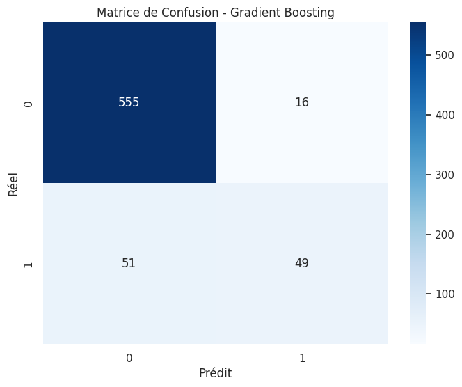

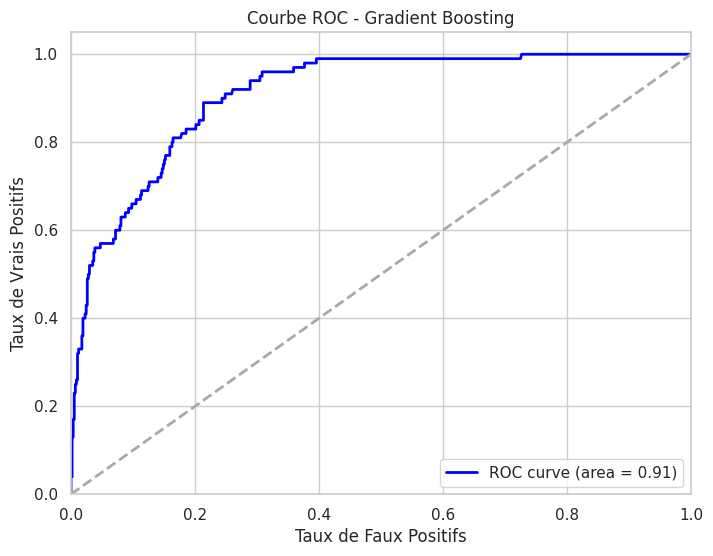

```python
# Configuration du modèle de Gradient Boosting
gradient_boosting_model = GradientBoostingClassifier(random_state=42)

# Grille d'hyperparamètres
param_grid = {
    'n_estimators': [100, 200, 300],
    'learning_rate': [0.01, 0.1, 0.2],
    'max_depth': [3, 5, 7],
    'min_samples_split': [2, 5, 10],
    'min_samples_leaf': [1, 2, 4]
}

# Recherche des meilleurs hyperparamètres
grid_search = GridSearchCV(gradient_boosting_model, param_grid, cv=5, scoring='accuracy')
grid_search.fit(X_train, y_train)

# Meilleur modèle
best_gradient_model = grid_search.best_estimator_

# Prédiction sur l'ensemble de test
y_pred_gradient = best_gradient_model.predict(X_test)
y_proba_gradient = best_gradient_model.predict_proba(X_test)[:, 1]

# Évaluation du modèle
conf_matrix_gradient = confusion_matrix(y_test, y_pred_gradient)
class_report_gradient = classification_report(y_test, y_pred_gradient)
auc_score_gradient = roc_auc_score(y_test, y_proba_gradient)

# Affichage des résultats
print("Meilleurs paramètres:", grid_search.best_params_)
print("Matrice de confusion:\n", conf_matrix_gradient)
print("Rapport de classification:\n", class_report_gradient)
print("AUC-ROC:", auc_score_gradient)

# Visualisation de la matrice de confusion
plt.figure(figsize=(8, 6))
sns.heatmap(conf_matrix_gradient, annot=True, fmt='d', cmap='Blues')
plt.title('Matrice de Confusion - Gradient Boosting')
plt.xlabel('Prédit')
plt.ylabel('Réel')
plt.show()

# Tracé de la courbe ROC
fpr, tpr, _ = roc_curve(y_test, y_proba_gradient)
plt.figure(figsize=(8, 6))
plt.plot(fpr, tpr, color='blue', lw=2, label=f'ROC curve (area = {auc_score_gradient:.2f})')
plt.plot([0, 1], [0, 1], color='darkgrey', lw=2, linestyle='--')
plt.xlim([0.0, 1.0])
plt.ylim([0.0, 1.05])
plt.xlabel('Taux de Faux Positifs')
plt.ylabel('Taux de Vrais Positifs')
plt.title('Courbe ROC - Gradient Boosting')
plt.legend(loc='lower right')
plt.show()
```

### Comparaison des Performances du Modèle de Gradient Boosting avec le Modèle de Régression Logistique Ajusté

Le modèle de Gradient Boosting a été optimisé avec des paramètres spécifiques, aboutissant à une précision globale de 90% et un score AUC-ROC de 0.909. Bien que ces résultats soient impressionnants, une comparaison avec notre modèle de régression logistique ajusté (Modèle 2) révèle des perspectives intéressantes.

Notre Modèle 2 de régression logistique, avec des classes pondérées pour tenir compte du déséquilibre, montre une précision globale légèrement inférieure de 81.7%. Toutefois, il présente un rappel remarquable de 78% pour la classe minoritaire, ce qui est essentiel dans notre contexte de campagne marketing où l'identification précise des réponses positives est cruciale.

Bien que le Gradient Boosting offre une meilleure performance globale en termes de précision et de score AUC-ROC, le modèle de régression logistique ajusté affiche une meilleure capacité à détecter les réponses positives (classe minoritaire), malgré une précision inférieure pour cette classe. Cela met en évidence un compromis entre la précision globale et la capacité à identifier les réponses positives.

Cette comparaison souligne l'importance de choisir un modèle qui non seulement présente de bonnes performances globales mais répond également aux besoins spécifiques de notre projet. Dans notre cas, la capacité à détecter efficacement les réponses positives est privilégiée, ce qui rend le modèle de régression logistique ajusté plus adapté malgré sa précision globale légèrement inférieure.

En conclusion, bien que le Gradient Boosting soit un modèle puissant et performant, notre Modèle 2 de régression logistique reste préférable pour notre objectif de maximiser les réponses positives dans les campagnes marketing, en raison de sa capacité supérieure à équilibrer précision et rappel pour les deux classes.

# Conclusion

Notre projet d'analyse de campagne marketing visait à identifier les facteurs influençant les réponses positives des clients. En utilisant un modèle de régression logistique ajusté pour le déséquilibre des classes (Modèle 2), nous avons pu obtenir des perspectives significatives sur les caractéristiques déterminantes pour une campagne marketing ciblée.

Les coefficients du modèle indiquent que l'acceptation des campagnes précédentes et des variables liées à la récence des achats, aux dépenses en vins, et au niveau d'éducation sont des prédicteurs importants de la réponse du client. Cela suggère que les campagnes historiques et les habitudes d'achat actuelles jouent un rôle crucial dans la prédiction des réponses des clients.

Un aspect notable de notre approche était l'absence d'une étape préalable de sélection des variables, préférant laisser les modèles déterminer l'importance des différentes caractéristiques. Cette décision pourrait être réévaluée dans les futures itérations du projet pour améliorer encore les performances du modèle.

Par ailleurs, la présence des variables de campagnes historiques soulève des questions sur la multicollinéarité et leur véritable impact sur les réponses. Une analyse plus approfondie de ces variables pourrait fournir des perspectives supplémentaires, en particulier pour déterminer si elles représentent des campagnes distinctes ou similaires.

En conclusion, bien que notre modèle actuel offre une base solide pour la compréhension des dynamiques des campagnes marketing, il existe des opportunités d'amélioration. L'exploration de techniques supplémentaires de sélection des variables et une investigation plus approfondie des variables de campagne historiques pourraient enrichir nos analyses futures, menant à des stratégies de marketing encore plus efficaces et ciblées.

# Merci 🙏

Nous tenons à exprimer notre gratitude pour votre engagement et votre travail acharné tout au long du cours. Votre contribution a été essentielle à notre succès.

Bonne Fête 🎉 et Bonne Année 2024 🎆!

Que cette nouvelle année apporte santé, bonheur et prospérité à vous et à vos proches.